# Introduction to R/Jupyter

This is a Jupyter Notebook. A Jupyter Notebook is an ["open-source web application that allows you to create and share documents that contain live code, equations, visualizations and narrative text."](http://jupyter.org) We will use the R programming languge and LaTex typsetting in Jupyter to prepare assignments and projects (you can also use other languages in Jupyter). The purpose of this note book is to familiarize yourself with programming in R.

R is a powerful open source programming language that is used for statistical computation and graphics. In many ways, it is similar to Matlab and Python (so, if you know these languages, learning R will be fairly easy!).

The best way to learn R and Jupyter is to jump right in! Below we walk through how to use Jupyter and R. **Text in boldface indicates exercises that I am asking you to complete.**

```r
#This package will be used to autograde some of your answers
library(testthat)
```

## Part I: Basics

Jupyter has different types of cells. This cell is a "markdown" cell, and is used to write equations (LaTeX) and text. The other type of cell that we will use is a "code" cell. This is where we will program using R. You can create a new cell from the plus sign above (delete using the scissor) and select the type of cell using the drop down menu above and to the right.

Note:

1. In autograded assignments, don't add or delete cells. This will impact the autograder.
2. Here's a [LaTeX cheatsheet](http://wch.github.io/latexsheet/).

#### Double click on the "Type Markdown and LaTex: $a^2$" and type your favorite equation (come on, you know you have one...).

$$ x_{n+1} = x_n - \frac{f(x_n)}{f'(x_n)} $$

In R/code cells, you can do (almost) anything that you can do in R, from basic computations to complex statistical modeling.

#### Create an R code cell below this cell. Compute the natural log of e. You may have guessed that the right functions for this are `log()` and `exp()`. But with R, you don't have to guess. You can type `?? log` to get some general information about functions related to logarithms (the same applies to other concepts); if you type "? X" you will get information about the specific function X (e.g., try `? exp`). Often, a Google search is a really effective way to learn about R functions.

```r
log(exp(1))
```

1

The function `c()` will allow you to create vectors ("c" for combine).

#### In the cell below, create three vectors:

```r
c(1,2,5.3,6,-2,4)
c("one","two", "three")
c(TRUE, TRUE, FALSE, FALSE)
```

1. 1

2. 2

3. 5.3

4. 6

5. -2

6. 4

1. 'one'

2. 'two'

3. 'three'

1. TRUE

2. TRUE

3. FALSE

4. FALSE

#### Next, type `seq(1,10)` in the R cell below. What does it do? What about `seq(1, 20, by = 2)`? `seq(10, 20, len = 100)`? Why are these convenient?

```r
seq(1,10)
seq(1,20, by = 2)
seq(10,20, len = 100)
# They are import to create arrays or to use them for, for-loops.
```

1. 1

2. 2

3. 3

4. 4

5. 5

6. 6

7. 7

8. 8

9. 9

10. 10

1. 1

2. 3

3. 5

4. 7

5. 9

6. 11

7. 13

8. 15

9. 17

10. 19

1. 10

2. 10.1010101010101

3. 10.2020202020202

4. 10.3030303030303

5. 10.4040404040404

6. 10.5050505050505

7. 10.6060606060606

8. 10.7070707070707

9. 10.8080808080808

10. 10.9090909090909

11. 11.010101010101

12. 11.1111111111111

13. 11.2121212121212

14. 11.3131313131313

15. 11.4141414141414

16. 11.5151515151515

17. 11.6161616161616

18. 11.7171717171717

19. 11.8181818181818

20. 11.9191919191919

21. 12.020202020202

22. 12.1212121212121

23. 12.2222222222222

24. 12.3232323232323

25. 12.4242424242424

26. 12.5252525252525

27. 12.6262626262626

28. 12.7272727272727

29. 12.8282828282828

30. 12.9292929292929

31. 13.030303030303

32. 13.1313131313131

33. 13.2323232323232

34. 13.3333333333333

35. 13.4343434343434

36. 13.5353535353535

37. 13.6363636363636

38. 13.7373737373737

39. 13.8383838383838

40. 13.9393939393939

41. 14.040404040404

42. 14.1414141414141

43. 14.2424242424242

44. 14.3434343434343

45. 14.4444444444444

46. 14.5454545454545

47. 14.6464646464646

48. 14.7474747474747

49. 14.8484848484848

50. 14.9494949494949

51. 15.0505050505051

52. 15.1515151515152

53. 15.2525252525253

54. 15.3535353535354

55. 15.4545454545455

56. 15.5555555555556

57. 15.6565656565657

58. 15.7575757575758

59. 15.8585858585859

60. 15.959595959596

61. 16.0606060606061

62. 16.1616161616162

63. 16.2626262626263

64. 16.3636363636364

65. 16.4646464646465

66. 16.5656565656566

67. 16.6666666666667

68. 16.7676767676768

69. 16.8686868686869

70. 16.969696969697

71. 17.0707070707071

72. 17.1717171717172

73. 17.2727272727273

74. 17.3737373737374

75. 17.4747474747475

76. 17.5757575757576

77. 17.6767676767677

78. 17.7777777777778

79. 17.8787878787879

80. 17.979797979798

81. 18.0808080808081

82. 18.1818181818182

83. 18.2828282828283

84. 18.3838383838384

85. 18.4848484848485

86. 18.5858585858586

87. 18.6868686868687

88. 18.7878787878788

89. 18.8888888888889

90. 18.989898989899

91. 19.0909090909091

92. 19.1919191919192

93. 19.2929292929293

94. 19.3939393939394

95. 19.4949494949495

96. 19.5959595959596

97. 19.6969696969697

98. 19.7979797979798

99. 19.8989898989899

100. 20

#### What does the `rep()` function do? This function can take in several arguments. To see what they are, use the help file! Explore the arguments `times` and `each`. What do they do?

```r
rep('Brian', times = 5)
rep(c(1,2,30), each = 3 )
```

1. 'Brian'

2. 'Brian'

3. 'Brian'

4. 'Brian'

5. 'Brian'

1. 1

2. 1

3. 1

4. 2

5. 2

6. 2

7. 30

8. 30

9. 30

You can store vectors in R using ${\tt =}$ or ${\tt <-}$.

#### Store the numbers 1 through 5 in a vector `v1`. Create another vector, `v2`, and join it together in a new vector, `new`.

*Note: This will be an autograded answer. The autograder will check whether you store the correct values in `v1`*.

```r
#assign 1, 2, 3, 4, 5 to the variable v1

#accessing data stored in variable v1
v1 = c(seq(1,5))
#create two vectors, then join them together in a new vector
v2 = c(seq(6,10))
new = c(v1, v2)
new
```

1. 1

2. 2

3. 3

4. 4

5. 5

6. 6

7. 7

8. 8

9. 9

10. 10

```r
# Test Cell
```

Factors, also known as categorical/qualitative variables, are important in statistics. "Shoe color" (Black, Brown, etc.), "drink size" (S, M, L) and "espresso roast" (Light, Medium, Dark) are examples of factors. Below, in `f1`, create a factor with six groups, labeled 1 through 6 using the `factor()` and `rep()` functions; note that R treats these values as factors; so, for example, you can't multiply `f1` by a number. Try multiplying `f1` by 3...

```r
#YOUR CODE HERE

f1 = factor(rep(c(seq(1,6)), each = 6))
f1
f2 = factor(c("a",7,"blue", "blue"))
f2
```

1. 1

2. 1

3. 1

4. 1

5. 1

6. 1

7. 2

8. 2

9. 2

10. 2

11. 2

12. 2

13. 3

14. 3

15. 3

16. 3

17. 3

18. 3

19. 4

20. 4

21. 4

22. 4

23. 4

24. 4

25. 5

26. 5

27. 5

28. 5

29. 5

30. 5

31. 6

32. 6

33. 6

34. 6

35. 6

36. 6

**Levels**:**

1. '1'

2. '2'

3. '3'

4. '4'

5. '5'

6. '6'

1. a

2. 7

3. blue

4. blue

**Levels**:**

1. '7'

2. 'a'

3. 'blue'

```r
# Test Cell
```

#### In the code cell below, I've written several commonly used functions. Explore. Change/add some arguments. See the power of R!

Note that the first function creates (pseudo) random numbers from a normal distribution. Don't worry if you don't know what that is yet; we'll learn about it. But R can generate random numbers...that's cool!

[output not shown]

50

243.966677567467

4.87933355134934

1.06834588586408

1.03360818778882

5.00954011159912

1. 2.31342558138895

2. 7.21780131068623

1. 1.54823667331394

2. 0.83872936173665

3. 1.75822518576646

4. 1.77586650945998

5. 1.7481964550428

6. 1.46508445891187

7. 1.64374327870373

8. 1.66040018313652

9. 1.20003741882875

10. 1.38999481150725

11. 1.4264804937387

12. 1.36092377560379

13. 1.976550378921

14. 1.82953253004384

15. 1.68868710151949

16. 1.56153487818164

17. 1.20446789937823

18. 1.71972356532093

19. 1.55763718136302

20. 1.62471737169222

21. 1.650043592849

22. 1.80017943686966

23. 1.64507562334299

24. 1.32629951081271

25. 1.52058427950383

26. 1.56512530909348

27. 1.57434197311807

28. 1.56726222316302

29. 1.6432691320341

30. 1.90009168917458

31. 1.75028595612623

32. 1.08042997710757

33. 1.52091097928953

34. 1.8618852704734

35. 1.40195424207133

36. 1.55886981198629

37. 1.64286254528319

38. 1.74921571463382

39. 1.05656243266812

40. 1.51492741967923

41. 1.69068206843991

42. 1.60258293422321

43. 1.67351141741317

44. 1.62002920721436

45. 1.30711404406209

46. 1.73909628597375

47. 1.77119256674211

48. 1.69636247416615

49. 1.56708764069961

50. 1.01506810811507

```
   Min. 1st Qu.  Median    Mean 3rd Qu.    Max.
  2.313   4.383   5.010   4.879   5.551   7.218
```

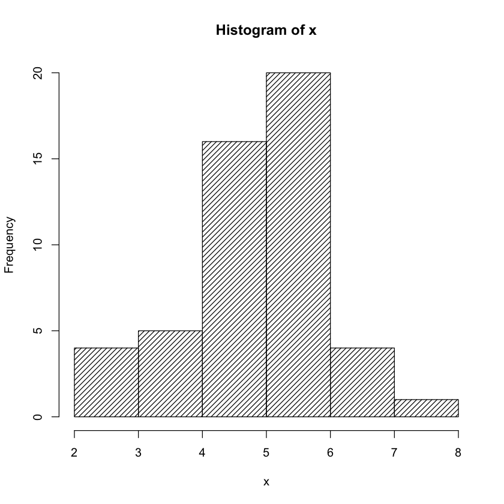

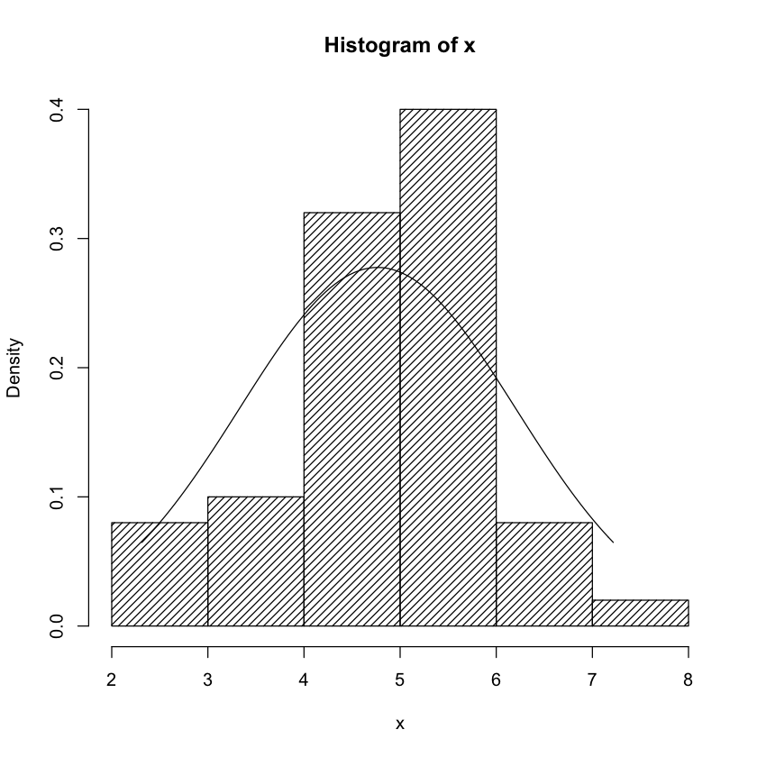

```r
x <- rnorm(50, mean=5, sd=1) #generates 50 random numbers from a gaussian with mean 5 and sd 1. Don't worry...you'll know what this means soon!

hist(x, density = 20)
length(x) #return the length of x
sum(x) #sum the numbers in x
mean(x) #calculate the mean of the numbers in x
var(x) #calculate the variance of the numbers in x
sd(x) #calculate the standard deviation of x
median(x) #calculate the median of x
range(x) #calculate the range of x
log(x) #calculate the natural log of x
summary(x) #return 5-number summary of x

hist(x, density = 20, freq = FALSE) #histogram of those random numbers; freq = FALSE makes x a 'density' (integrates to 1); density shades the boxes
curve(dnorm(x,mean = mean(x),sd = sd(x)),from = min(x), to = max(x), add = TRUE) #overlay of normal density
```

# Part II: Vector Indexing

R (like Matlab and Python) has a nice indexing system. Given a matrix $A$, we can access the $[i,j]$ element of $A$ by writing `A[i,j]`. We can access the $i^{th}$ row by typing `A[i,]`. And, we can access the $j^{th}$ column by typing `A[,j]`. And, we can do even fancier things too...

#### Modify the third line of code below to access the second, fourth, and sixth elements of the vector `a`. Take note of whether R starts indexing at 0 or 1! Also, note that the last line uses the minus sign to access elements *other than* those specified in the index.

```r
a = seq(2, 16, by = 2)
a
a[c(2, 4, 6)]

###
a[-c(1,5)]
```

1. 2

2. 4

3. 6

4. 8

5. 10

6. 12

7. 14

8. 16

1. 4

2. 8

3. 12

1. 4

2. 6

3. 8

4. 12

5. 14

6. 16

#### Write code that prints the third through sixth elements of `a` and store it in a variable `b` (there's a short and long way).

```r
b = a[seq(3,6)]
b
```

1. 6

2. 8

3. 10

4. 12

```r
# Test Cell
```

Logical indexing is another powerful tool for working with data in R.

#### Let's start with typing things like `a > 10`, `a <= 4`, `a == 10`, and `a != 10`. What do these lines do?

```r
a != 10
```

1. TRUE

2. TRUE

3. TRUE

4. TRUE

5. FALSE

6. TRUE

7. TRUE

8. TRUE

Now let's look at more complicated logical statements. Note that ${\tt \&}$ represents "and", and ${\tt |}$ represents "or" in R.

#### Write code that prints ${\tt TRUE}$ for values of $a$ greater than 6 and less than or equal to 10, and ${\tt FALSE}$ otherwise. Then, write code that prints ${\tt TRUE}$ for values of $a$ less than or equal to 4 or greater or equal to 12, and ${\tt FALSE}$ otherwise.

```r
a > 6 & a <= 10
a <= 4 | a >= 12
```

1. FALSE

2. FALSE

3. FALSE

4. TRUE

5. TRUE

6. FALSE

7. FALSE

8. FALSE

1. TRUE

2. TRUE

3. FALSE

4. FALSE

5. FALSE

6. TRUE

7. TRUE

8. TRUE

The real power of logical indexing comes when we take these vectors of logicals and put them in the index of a vector. The first line below tells R to print all elements of `a` such that `a < 6`.

#### Write code to print elements of `a` equal to 10. Then, print elements of `a` less than six or equal to 10.

```r
a[a==10]
a[a < 6 | a ==10]
```

10

1. 2

2. 4

3. 10

## Part III: Functions, Loops and Beyond!

As we've seen, R has many built in functions; but, you can write your own, too! Below is the syntax.

#### Write a function that concatenates two vectors.

```r
y = function(v1, v2){
    return(c(v1,v2))
}
```

The function f1 below produces results like 'T' 'H' 'T' 'T'. We can think of `f1` a function that flips a coin four times.

#### Write a function `f2` that can be interpreted as rolling a fair die eight times. How could you modify the code to roll a biased die?

#### Notice that every time you run these function, the results are different! Uncomment the line `set.seed(99)` and notice what happens.

```r
set.seed(99)
f1 = function(){
    s = sample(c("H", "T"), size = 4, replace = TRUE)
    return(s)
}

f1()

f2 = function(){
    d = c(1,2,3,4,5,6)
    s = sample(d, size = 8, replace = TRUE)
    return(s)
}
f2()
```

1. 'T'

2. 'H'

3. 'T'

4. 'T'

1. 6

2. 5

3. 3

4. 2

5. 6

6. 2

7. 6

8. 5

In R, just like in C++, Matlab, Python, etc., you can write loops to repeat a sequence of instructions until a certain condition is met.

#### Below is the syntax for a loop. Inside the loop, write a line of code that populates the matrix `M` with the numbers 1 through 20.

```r
n = 20;
M = matrix(NA, ncol = 2, nrow = 10); #check the help file so that you know what this does!


for (i in 1:n){
    M[i] = i
}
M
```

| 1 | 11 |
| --- | --- |
| 2 | 12 |
| 3 | 13 |
| 4 | 14 |
| 5 | 15 |
| 6 | 16 |
| 7 | 17 |
| 8 | 18 |
| 9 | 19 |
| 10 | 20 |

#### Now, write a loop to calculate the mean of each column of `M`.

```r
m = matrix(NA, nrow = 2, ncol = 1)
for (i in 1:2){
    m[i] = i
}
m
colMeans(m)
```

| 1 |
| --- |
| 2 |

1.5

### Here's an incredibly important lesson about R: many tasks that require loops in other languages (e.g., C++) *do not* require loops in R.

#### As an example, use the function `colMeans()` to calculate the means of the columns of `M` without a loop. Store these means in a variable `M_means`. Then, look at the help file for `colMeans()` to see related functions.

```r
M_means = colMeans(M)
M_means
? colMeans()
```

1. 5.5

2. 15.5

```r
# Test Cell
```

Note that the family of functions that includes `colMeans()` does not include a function to calculate the standard deviation or variance of a column (or row). But we can still do this without loops, using the `apply()` function.

**Below, the `apply()` function is set up to calculate the variance of each row of M. Modify the code to calculate the standard deviation of each column of M. Store your answer in `col_sd`.**

```r
? apply()
apply(M, 2, sd)
```

1. 3.02765035409749

2. 3.02765035409749

```r
# Test Cell
```

Recall above that we wrote a function `f1` that flips a coin four times. As odd as it sounds, it will become desirable for us to repeat many times (say, $m$ times) the process of flipping a coin four times. The result might be a matrix with $m$ rows and four columns.

#### Write a loop to repeat the process of "flipping a coin four times" 10,000 times. The result should be a 10,000 by 4 matrix.

```r
z = 10000
coin = matrix(NA, nrow = z, ncol = 4)
for (x in 1:z){
    s = sample(c("H", "T"), size = 4, replace = TRUE)
    coin[x,] = s
}
coin
```

| H | T | T | H |
| --- | --- | --- | --- |
| H | H | T | T |
| H | T | T | T |
| T | H | T | H |
| T | H | H | H |
| T | T | H | H |
| T | H | H | T |
| T | H | T | T |
| H | H | T | H |
| T | T | H | T |
| H | T | T | H |
| T | H | T | H |
| T | T | H | T |
| H | H | H | H |
| T | H | H | H |
| H | H | T | H |
| T | H | H | H |
| T | T | H | H |
| T | T | T | T |
| H | H | H | T |
| H | T | H | H |
| H | H | T | T |
| T | H | T | T |
| H | H | T | H |
| H | T | T | T |
| H | T | T | H |
| H | T | T | H |
| T | H | H | T |
| H | T | H | H |
| T | H | H | H |
| ... | ... | ... | ... |
| T | T | T | T |
| T | T | T | T |
| H | T | T | H |
| T | T | T | T |
| H | T | T | T |
| T | T | T | H |
| T | H | H | T |
| H | T | H | H |
| H | H | T | T |
| T | H | T | T |
| T | H | H | H |
| T | T | H | T |
| H | H | H | H |
| H | T | T | H |
| H | T | T | T |
| T | T | H | T |
| T | H | T | H |
| H | T | H | T |
| T | T | T | H |
| H | T | H | H |
| H | H | T | H |
| T | H | H | H |
| H | H | H | H |
| H | H | T | T |
| H | H | H | H |
| H | T | T | H |
| T | H | T | H |
| H | H | T | T |
| H | T | T | T |
| H | T | T | T |

But, as master R programmers, we avoid loops whenever possible. One reason why we do this is because loops are slower than the fancy R alternatives. As an alternative to the loop above, let's use the `replicate()` function to repeat the coin flipping process.

#### Using the help function as your guide, use `replicate()` to repeat the process of "flipping a coin four times" 10,000 times.

```r
i = 10000
replicate(i, sample(c("H", "T"), size = 4, replace = TRUE), simplify = FALSE)
```

1. 1. 'H'

   2. 'H'

   3. 'H'

   4. 'T'

2. 1. 'H'

   2. 'T'

   3. 'T'

   4. 'T'

3. 1. 'H'

   2. 'T'

   3. 'H'

   4. 'H'

4. 1. 'H'

   2. 'T'

   3. 'H'

   4. 'T'

5. 1. 'T'

   2. 'T'

   3. 'T'

   4. 'H'

6. 1. 'H'

   2. 'H'

   3. 'T'

   4. 'T'

7. 1. 'T'

   2. 'T'

   3. 'T'

   4. 'H'

8. 1. 'H'

   2. 'H'

   3. 'T'

   4. 'H'

9. 1. 'T'

   2. 'T'

   3. 'T'

   4. 'H'

10. 1. 'H'

    2. 'H'

    3. 'H'

    4. 'T'

11. 1. 'H'

    2. 'H'

    3. 'H'

    4. 'T'

12. 1. 'H'

    2. 'T'

    3. 'T'

    4. 'T'

13. 1. 'T'

    2. 'H'

    3. 'H'

    4. 'T'

14. 1. 'H'

    2. 'T'

    3. 'T'

    4. 'H'

15. 1. 'T'

    2. 'H'

    3. 'T'

    4. 'H'

16. 1. 'H'

    2. 'H'

    3. 'H'

    4. 'H'

17. 1. 'H'

    2. 'H'

    3. 'H'

    4. 'H'

18. 1. 'T'

    2. 'H'

    3. 'T'

    4. 'T'

19. 1. 'T'

    2. 'T'

    3. 'H'

    4. 'T'

20. 1. 'H'

    2. 'T'

    3. 'T'

    4. 'T'

21. 1. 'T'

    2. 'H'

    3. 'T'

    4. 'H'

22. 1. 'T'

    2. 'T'

    3. 'H'

    4. 'H'

23. 1. 'T'

    2. 'H'

    3. 'T'

    4. 'T'

24. 1. 'H'

    2. 'H'

    3. 'H'

    4. 'H'

25. 1. 'H'

    2. 'T'

    3. 'H'

    4. 'H'

26. 1. 'T'

    2. 'T'

    3. 'T'

    4. 'H'

27. 1. 'T'

    2. 'H'

    3. 'T'

    4. 'T'

28. 1. 'H'

    2. 'H'

    3. 'T'

    4. 'H'

29. 1. 'T'

    2. 'H'

    3. 'T'

    4. 'H'

30. 1. 'T'

    2. 'T'

    3. 'T'

    4. 'H'

31. 1. 'T'

    2. 'T'

    3. 'H'

    4. 'H'

32. 1. 'H'

    2. 'T'

    3. 'H'

    4. 'H'

33. 1. 'T'

    2. 'H'

    3. 'T'

    4. 'T'

34. 1. 'H'

    2. 'H'

    3. 'H'

    4. 'T'

35. 1. 'T'

    2. 'T'

    3. 'H'

    4. 'H'

36. 1. 'T'

    2. 'H'

    3. 'H'

    4. 'H'

37. 1. 'T'

    2. 'T'

    3. 'H'

    4. 'T'

38. 1. 'H'

    2. 'T'

    3. 'T'

    4. 'H'

39. 1. 'H'

    2. 'T'

    3. 'T'

    4. 'H'

40. 1. 'H'

    2. 'T'

    3. 'T'

    4. 'T'

41. 1. 'T'

    2. 'T'

    3. 'H'

    4. 'T'

42. 1. 'T'

    2. 'H'

    3. 'T'

    4. 'H'

43. 1. 'H'

    2. 'T'

    3. 'T'

    4. 'T'

44. 1. 'H'

    2. 'T'

    3. 'H'

    4. 'T'

45. 1. 'H'

    2. 'T'

    3. 'H'

    4. 'H'

46. 1. 'T'

    2. 'H'

    3. 'T'

    4. 'H'

47. 1. 'H'

    2. 'H'

    3. 'H'

    4. 'H'

48. 1. 'T'

    2. 'T'

    3. 'H'

    4. 'T'

49. 1. 'H'

    2. 'T'

    3. 'T'

    4. 'H'

50. 1. 'H'

    2. 'H'

    3. 'T'

    4. 'T'

51. 1. 'H'

    2. 'T'

    3. 'H'

    4. 'T'

52. 1. 'H'

    2. 'H'

    3. 'T'

    4. 'T'

53. 1. 'T'

    2. 'T'

    3. 'T'

    4. 'H'

54. 1. 'T'

    2. 'T'

    3. 'T'

    4. 'H'

55. 1. 'T'

    2. 'T'

    3. 'H'

    4. 'H'

56. 1. 'H'

    2. 'H'

    3. 'H'

    4. 'H'

57. 1. 'H'

    2. 'T'

    3. 'H'

    4. 'H'

58. 1. 'H'

    2. 'T'

    3. 'H'

    4. 'H'

59. 1. 'H'

    2. 'T'

    3. 'H'

    4. 'T'

60. 1. 'T'

    2. 'H'

    3. 'H'

    4. 'H'

61. 1. 'H'

    2. 'H'

    3. 'H'

    4. 'H'

62. 1. 'H'

    2. 'T'

    3. 'H'

    4. 'H'

63. 1. 'T'

    2. 'T'

    3. 'T'

    4. 'T'

64. 1. 'H'

    2. 'T'

    3. 'T'

    4. 'T'

65. 1. 'T'

    2. 'H'

    3. 'T'

    4. 'H'

66. 1. 'T'

    2. 'H'

    3. 'H'

    4. 'T'

67. 1. 'H'

    2. 'T'

    3. 'T'

    4. 'H'

68. 1. 'H'

    2. 'H'

    3. 'H'

    4. 'H'

69. 1. 'H'

    2. 'T'

    3. 'H'

    4. 'T'

70. 1. 'T'

    2. 'H'

    3. 'H'

    4. 'T'

71. 1. 'H'

    2. 'T'

    3. 'H'

    4. 'T'

72. 1. 'H'

    2. 'T'

    3. 'H'

    4. 'H'

73. 1. 'T'

    2. 'H'

    3. 'H'

    4. 'T'

74. 1. 'H'

    2. 'T'

    3. 'H'

    4. 'T'

75. 1. 'H'

    2. 'T'

    3. 'H'

    4. 'T'

76. 1. 'H'

    2. 'T'

    3. 'T'

    4. 'H'

77. 1. 'H'

    2. 'T'

    3. 'T'

    4. 'T'

78. 1. 'H'

    2. 'H'

    3. 'H'

    4. 'T'

79. 1. 'T'

    2. 'T'

    3. 'T'

    4. 'T'

80. 1. 'H'

    2. 'T'

    3. 'T'

    4. 'T'

81. 1. 'H'

    2. 'H'

    3. 'H'

    4. 'T'

82. 1. 'T'

    2. 'H'

    3. 'T'

    4. 'H'

83. 1. 'T'

    2. 'H'

    3. 'H'

    4. 'T'

84. 1. 'H'

    2. 'T'

    3. 'T'

    4. 'T'

85. 1. 'T'

    2. 'T'

    3. 'H'

    4. 'H'

86. 1. 'T'

    2. 'T'

    3. 'T'

    4. 'H'

87. 1. 'T'

    2. 'T'

    3. 'H'

    4. 'H'

88. 1. 'H'

    2. 'H'

    3. 'T'

    4. 'T'

89. 1. 'T'

    2. 'H'

    3. 'T'

    4. 'H'

90. 1. 'H'

    2. 'T'

    3. 'H'

    4. 'T'

91. 1. 'H'

    2. 'T'

    3. 'H'

    4. 'T'

92. 1. 'H'

    2. 'H'

    3. 'H'

    4. 'H'

93. 1. 'H'

    2. 'T'

    3. 'H'

    4. 'T'

94. 1. 'H'

    2. 'T'

    3. 'H'

    4. 'H'

95. 1. 'H'

    2. 'T'

    3. 'H'

    4. 'H'

96. 1. 'H'

    2. 'T'

    3. 'H'

    4. 'T'

97. 1. 'H'

    2. 'T'

    3. 'H'

    4. 'T'

98. 1. 'T'

    2. 'T'

    3. 'H'

    4. 'H'

99. 1. 'T'

    2. 'T'

    3. 'T'

    4. 'H'

100. 1. 'T'

     2. 'T'

     3. 'H'

     4. 'T'

101. 1. 'H'

     2. 'T'

     3. 'H'

     4. 'T'

102. 1. 'H'

     2. 'T'

     3. 'H'

     4. 'H'

103. 1. 'H'

     2. 'H'

     3. 'T'

     4. 'H'

104. 1. 'H'

     2. 'T'

     3. 'H'

     4. 'T'

105. 1. 'H'

     2. 'T'

     3. 'T'

     4. 'T'

106. 1. 'T'

     2. 'H'

     3. 'T'

     4. 'H'

107. 1. 'H'

     2. 'H'

     3. 'T'

     4. 'T'

108. 1. 'H'

     2. 'H'

     3. 'H'

     4. 'H'

109. 1. 'H'

     2. 'H'

     3. 'T'

     4. 'H'

110. 1. 'H'

     2. 'T'

     3. 'H'

     4. 'T'

111. 1. 'H'

     2. 'H'

     3. 'T'

     4. 'T'

112. 1. 'H'

     2. 'T'

     3. 'H'

     4. 'T'

113. 1. 'H'

     2. 'T'

     3. 'H'

     4. 'H'

114. 1. 'T'

     2. 'T'

     3. 'T'

     4. 'H'

115. 1. 'T'

     2. 'T'

     3. 'T'

     4. 'H'

116. 1. 'H'

     2. 'T'

     3. 'T'

     4. 'H'

117. 1. 'T'

     2. 'H'

     3. 'H'

     4. 'H'

118. 1. 'T'

     2. 'H'

     3. 'T'

     4. 'H'

119. 1. 'T'

     2. 'T'

     3. 'H'

     4. 'H'

120. 1. 'T'

     2. 'H'

     3. 'H'

     4. 'H'

121. 1. 'T'

     2. 'H'

     3. 'T'

     4. 'T'

122. 1. 'H'

     2. 'T'

     3. 'T'

     4. 'T'

123. 1. 'H'

     2. 'T'

     3. 'T'

     4. 'H'

124. 1. 'H'

     2. 'H'

     3. 'H'

     4. 'H'

125. 1. 'T'

     2. 'T'

     3. 'H'

     4. 'H'

126. 1. 'H'

     2. 'T'

     3. 'T'

     4. 'H'

127. 1. 'T'

     2. 'H'

     3. 'T'

     4. 'H'

128. 1. 'T'

     2. 'H'

     3. 'H'

     4. 'H'

129. 1. 'T'

     2. 'H'

     3. 'T'

     4. 'H'

130. 1. 'T'

     2. 'H'

     3. 'H'

     4. 'T'

131. 1. 'T'

     2. 'T'

     3. 'T'

     4. 'H'

132. 1. 'H'

     2. 'H'

     3. 'T'

     4. 'H'

133. 1. 'H'

     2. 'H'

     3. 'T'

     4. 'H'

134. 1. 'H'

     2. 'T'

     3. 'H'

     4. 'T'

135. 1. 'T'

     2. 'H'

     3. 'T'

     4. 'H'

136. 1. 'T'

     2. 'T'

     3. 'T'

     4. 'T'

137. 1. 'T'

     2. 'H'

     3. 'H'

     4. 'H'

138. 1. 'H'

     2. 'H'

     3. 'T'

     4. 'T'

139. 1. 'T'

     2. 'H'

     3. 'H'

     4. 'T'

140. 1. 'H'

     2. 'T'

     3. 'T'

     4. 'T'

141. 1. 'H'

     2. 'H'

     3. 'H'

     4. 'T'

142. 1. 'H'

     2. 'T'

     3. 'H'

     4. 'H'

143. 1. 'T'

     2. 'H'

     3. 'H'

     4. 'T'

144. 1. 'H'

     2. 'H'

     3. 'H'

     4. 'T'

145. 1. 'H'

     2. 'T'

     3. 'H'

     4. 'T'

146. 1. 'H'

     2. 'H'

     3. 'T'

     4. 'H'

147. 1. 'T'

     2. 'H'

     3. 'H'

     4. 'T'

148. 1. 'H'

     2. 'T'

     3. 'T'

     4. 'T'

149. 1. 'H'

     2. 'T'

     3. 'H'

     4. 'T'

150. 1. 'H'

     2. 'T'

     3. 'T'

     4. 'H'

151. 1. 'H'

     2. 'T'

     3. 'T'

     4. 'H'

152. 1. 'H'

     2. 'T'

     3. 'H'

     4. 'T'

153. 1. 'H'

     2. 'H'

     3. 'H'

     4. 'H'

154. 1. 'T'

     2. 'H'

     3. 'T'

     4. 'T'

155. 1. 'T'

     2. 'H'

     3. 'T'

     4. 'T'

156. 1. 'T'

     2. 'H'

     3. 'T'

     4. 'T'

157. 1. 'T'

     2. 'H'

     3. 'T'

     4. 'T'

158. 1. 'H'

     2. 'T'

     3. 'T'

     4. 'T'

159. 1. 'T'

     2. 'T'

     3. 'H'

     4. 'T'

160. 1. 'T'

     2. 'T'

     3. 'T'

     4. 'H'

161. 1. 'T'

     2. 'H'

     3. 'H'

     4. 'T'

162. 1. 'H'

     2. 'H'

     3. 'H'

     4. 'H'

163. 1. 'H'

     2. 'T'

     3. 'T'

     4. 'H'

164. 1. 'H'

     2. 'H'

     3. 'T'

     4. 'H'

165. 1. 'H'

     2. 'H'

     3. 'T'

     4. 'T'

166. 1. 'T'

     2. 'H'

     3. 'T'

     4. 'H'

167. 1. 'H'

     2. 'T'

     3. 'T'

     4. 'T'

168. 1. 'T'

     2. 'H'

     3. 'T'

     4. 'H'

169. 1. 'T'

     2. 'H'

     3. 'H'

     4. 'T'

170. 1. 'T'

     2. 'H'

     3. 'T'

     4. 'T'

171. 1. 'T'

     2. 'T'

     3. 'H'

     4. 'T'

172. 1. 'T'

     2. 'T'

     3. 'T'

     4. 'H'

173. 1. 'H'

     2. 'H'

     3. 'T'

     4. 'H'

174. 1. 'T'

     2. 'T'

     3. 'H'

     4. 'T'

175. 1. 'H'

     2. 'H'

     3. 'T'

     4. 'T'

176. 1. 'H'

     2. 'T'

     3. 'H'

     4. 'T'

177. 1. 'H'

     2. 'T'

     3. 'T'

     4. 'H'

178. 1. 'H'

     2. 'T'

     3. 'H'

     4. 'H'

179. 1. 'H'

     2. 'T'

     3. 'H'

     4. 'H'

180. 1. 'H'

     2. 'T'

     3. 'H'

     4. 'T'

181. 1. 'H'

     2. 'H'

     3. 'T'

     4. 'T'

182. 1. 'H'

     2. 'T'

     3. 'T'

     4. 'H'

183. 1. 'H'

     2. 'T'

     3. 'H'

     4. 'H'

184. 1. 'T'

     2. 'T'

     3. 'T'

     4. 'T'

185. 1. 'T'

     2. 'T'

     3. 'T'

     4. 'T'

186. 1. 'H'

     2. 'T'

     3. 'T'

     4. 'H'

187. 1. 'T'

     2. 'T'

     3. 'H'

     4. 'T'

188. 1. 'H'

     2. 'H'

     3. 'H'

     4. 'T'

189. 1. 'H'

     2. 'H'

     3. 'H'

     4. 'H'

190. 1. 'T'

     2. 'H'

     3. 'H'

     4. 'H'

191. 1. 'H'

     2. 'H'

     3. 'T'

     4. 'H'

192. 1. 'T'

     2. 'T'

     3. 'T'

     4. 'H'

193. 1. 'H'

     2. 'T'

     3. 'T'

     4. 'T'

194. 1. 'H'

     2. 'T'

     3. 'H'

     4. 'T'

195. 1. 'H'

     2. 'T'

     3. 'H'

     4. 'T'

196. 1. 'H'

     2. 'H'

     3. 'T'

     4. 'T'

197. 1. 'H'

     2. 'H'

     3. 'T'

     4. 'T'

198. 1. 'T'

     2. 'H'

     3. 'T'

     4. 'H'

199. 1. 'H'

     2. 'H'

     3. 'T'

     4. 'T'

200. 1. 'T'

     2. 'T'

     3. 'H'

     4. 'H'

201. 1. 'T'

     2. 'T'

     3. 'H'

     4. 'T'

202. 1. 'T'

     2. 'T'

     3. 'H'

     4. 'H'

203. 1. 'T'

     2. 'T'

     3. 'H'

     4. 'T'

204. 1. 'T'

     2. 'T'

     3. 'T'

     4. 'H'

205. 1. 'T'

     2. 'T'

     3. 'T'

     4. 'H'

206. 1. 'T'

     2. 'H'

     3. 'H'

     4. 'T'

207. 1. 'H'

     2. 'H'

     3. 'H'

     4. 'H'

208. 1. 'T'

     2. 'T'

     3. 'H'

     4. 'H'

209. 1. 'T'

     2. 'T'

     3. 'T'

     4. 'H'

210. 1. 'H'

     2. 'T'

     3. 'H'

     4. 'T'

211. 1. 'T'

     2. 'H'

     3. 'H'

     4. 'T'

212. 1. 'T'

     2. 'T'

     3. 'H'

     4. 'H'

213. 1. 'T'

     2. 'T'

     3. 'H'

     4. 'H'

214. 1. 'H'

     2. 'T'

     3. 'H'

     4. 'T'

215. 1. 'H'

     2. 'H'

     3. 'H'

     4. 'H'

216. 1. 'T'

     2. 'H'

     3. 'H'

     4. 'T'

217. 1. 'T'

     2. 'T'

     3. 'H'

     4. 'H'

218. 1. 'H'

     2. 'H'

     3. 'H'

     4. 'H'

219. 1. 'T'

     2. 'H'

     3. 'H'

     4. 'H'

220. 1. 'H'

     2. 'H'

     3. 'T'

     4. 'T'

221. 1. 'T'

     2. 'T'

     3. 'H'

     4. 'H'

222. 1. 'T'

     2. 'T'

     3. 'H'

     4. 'T'

223. 1. 'T'

     2. 'T'

     3. 'H'

     4. 'T'

224. 1. 'T'

     2. 'T'

     3. 'T'

     4. 'T'

225. 1. 'H'

     2. 'H'

     3. 'T'

     4. 'T'

226. 1. 'H'

     2. 'H'

     3. 'T'

     4. 'H'

227. 1. 'H'

     2. 'H'

     3. 'H'

     4. 'T'

228. 1. 'T'

     2. 'H'

     3. 'H'

     4. 'H'

229. 1. 'T'

     2. 'H'

     3. 'T'

     4. 'H'

230. 1. 'T'

     2. 'T'

     3. 'H'

     4. 'T'

231. 1. 'T'

     2. 'H'

     3. 'H'

     4. 'H'

232. 1. 'H'

     2. 'H'

     3. 'T'

     4. 'T'

233. 1. 'T'

     2. 'H'

     3. 'T'

     4. 'H'

234. 1. 'H'

     2. 'H'

     3. 'H'

     4. 'H'

235. 1. 'H'

     2. 'T'

     3. 'H'

     4. 'H'

236. 1. 'T'

     2. 'T'

     3. 'H'

     4. 'H'

237. 1. 'T'

     2. 'T'

     3. 'H'

     4. 'H'

238. 1. 'H'

     2. 'H'

     3. 'H'

     4. 'T'

239. 1. 'H'

     2. 'T'

     3. 'H'

     4. 'T'

240. 1. 'H'

     2. 'T'

     3. 'T'

     4. 'H'

241. 1. 'T'

     2. 'T'

     3. 'T'

     4. 'T'

242. 1. 'T'

     2. 'T'

     3. 'T'

     4. 'T'

243. 1. 'H'

     2. 'T'

     3. 'H'

     4. 'T'

244. 1. 'T'

     2. 'T'

     3. 'T'

     4. 'T'

245. 1. 'T'

     2. 'T'

     3. 'T'

     4. 'T'

246. 1. 'T'

     2. 'H'

     3. 'T'

     4. 'H'

247. 1. 'H'

     2. 'T'

     3. 'H'

     4. 'T'

248. 1. 'T'

     2. 'H'

     3. 'H'

     4. 'T'

249. 1. 'H'

     2. 'H'

     3. 'T'

     4. 'T'

250. 1. 'T'

     2. 'H'

     3. 'T'

     4. 'T'

251. 1. 'T'

     2. 'H'

     3. 'T'

     4. 'H'

252. 1. 'T'

     2. 'H'

     3. 'H'

     4. 'H'

253. 1. 'H'

     2. 'T'

     3. 'H'

     4. 'H'

254. 1. 'T'

     2. 'H'

     3. 'T'

     4. 'T'

255. 1. 'H'

     2. 'T'

     3. 'H'

     4. 'H'

256. 1. 'H'

     2. 'H'

     3. 'H'

     4. 'H'

257. 1. 'H'

     2. 'T'

     3. 'T'

     4. 'H'

258. 1. 'T'

     2. 'T'

     3. 'H'

     4. 'H'

259. 1. 'H'

     2. 'T'

     3. 'H'

     4. 'T'

260. 1. 'H'

     2. 'H'

     3. 'T'

     4. 'H'

261. 1. 'H'

     2. 'H'

     3. 'T'

     4. 'T'

262. 1. 'T'

     2. 'T'

     3. 'H'

     4. 'H'

263. 1. 'H'

     2. 'H'

     3. 'H'

     4. 'H'

264. 1. 'T'

     2. 'T'

     3. 'H'

     4. 'H'

265. 1. 'T'

     2. 'H'

     3. 'H'

     4. 'H'

266. 1. 'H'

     2. 'H'

     3. 'H'

     4. 'H'

267. 1. 'T'

     2. 'T'

     3. 'H'

     4. 'T'

268. 1. 'T'

     2. 'T'

     3. 'T'

     4. 'T'

269. 1. 'T'

     2. 'T'

     3. 'T'

     4. 'H'

270. 1. 'H'

     2. 'T'

     3. 'H'

     4. 'T'

271. 1. 'H'

     2. 'H'

     3. 'T'

     4. 'H'

272. 1. 'T'

     2. 'H'

     3. 'H'

     4. 'H'

273. 1. 'H'

     2. 'T'

     3. 'T'

     4. 'T'

274. 1. 'H'

     2. 'H'

     3. 'H'

     4. 'H'

275. 1. 'T'

     2. 'T'

     3. 'T'

     4. 'T'

276. 1. 'T'

     2. 'T'

     3. 'H'

     4. 'H'

277. 1. 'T'

     2. 'T'

     3. 'T'

     4. 'H'

278. 1. 'T'

     2. 'T'

     3. 'H'

     4. 'T'

279. 1. 'T'

     2. 'T'

     3. 'H'

     4. 'H'

280. 1. 'T'

     2. 'H'

     3. 'H'

     4. 'T'

281. 1. 'H'

     2. 'H'

     3. 'H'

     4. 'T'

282. 1. 'H'

     2. 'T'

     3. 'H'

     4. 'H'

283. 1. 'T'

     2. 'H'

     3. 'H'

     4. 'T'

284. 1. 'H'

     2. 'T'

     3. 'H'

     4. 'T'

285. 1. 'T'

     2. 'T'

     3. 'H'

     4. 'T'

286. 1. 'T'

     2. 'T'

     3. 'H'

     4. 'H'

287. 1. 'T'

     2. 'T'

     3. 'T'

     4. 'H'

288. 1. 'H'

     2. 'H'

     3. 'H'

     4. 'H'

289. 1. 'T'

     2. 'T'

     3. 'H'

     4. 'T'

290. 1. 'H'

     2. 'T'

     3. 'H'

     4. 'H'

291. 1. 'T'

     2. 'H'

     3. 'H'

     4. 'H'

292. 1. 'H'

     2. 'H'

     3. 'H'

     4. 'H'

293. 1. 'T'

     2. 'T'

     3. 'T'

     4. 'T'

294. 1. 'H'

     2. 'T'

     3. 'T'

     4. 'H'

295. 1. 'T'

     2. 'H'

     3. 'T'

     4. 'H'

296. 1. 'T'

     2. 'H'

     3. 'T'

     4. 'T'

297. 1. 'T'

     2. 'T'

     3. 'H'

     4. 'T'

298. 1. 'T'

     2. 'H'

     3. 'T'

     4. 'T'

299. 1. 'T'

     2. 'T'

     3. 'T'

     4. 'T'

300. 1. 'H'

     2. 'T'

     3. 'H'

     4. 'H'

301. 1. 'H'

     2. 'T'

     3. 'H'

     4. 'H'

302. 1. 'H'

     2. 'T'

     3. 'T'

     4. 'T'

303. 1. 'T'

     2. 'H'

     3. 'H'

     4. 'T'

304. 1. 'H'

     2. 'H'

     3. 'T'

     4. 'T'

305. 1. 'H'

     2. 'T'

     3. 'T'

     4. 'T'

306. 1. 'H'

     2. 'T'

     3. 'T'

     4. 'H'

307. 1. 'H'

     2. 'H'

     3. 'H'

     4. 'H'

308. 1. 'T'

     2. 'H'

     3. 'H'

     4. 'H'

309. 1. 'T'

     2. 'T'

     3. 'T'

     4. 'H'

310. 1. 'T'

     2. 'T'

     3. 'H'

     4. 'T'

311. 1. 'T'

     2. 'T'

     3. 'T'

     4. 'H'

312. 1. 'T'

     2. 'T'

     3. 'T'

     4. 'H'

313. 1. 'T'

     2. 'H'

     3. 'T'

     4. 'T'

314. 1. 'T'

     2. 'T'

     3. 'T'

     4. 'T'

315. 1. 'H'

     2. 'T'

     3. 'T'

     4. 'T'

316. 1. 'T'

     2. 'T'

     3. 'T'

     4. 'T'

317. 1. 'T'

     2. 'T'

     3. 'H'

     4. 'T'

318. 1. 'H'

     2. 'T'

     3. 'T'

     4. 'T'

319. 1. 'T'

     2. 'T'

     3. 'T'

     4. 'T'

320. 1. 'H'

     2. 'H'

     3. 'T'

     4. 'T'

321. 1. 'T'

     2. 'H'

     3. 'H'

     4. 'T'

322. 1. 'T'

     2. 'T'

     3. 'H'

     4. 'T'

323. 1. 'H'

     2. 'T'

     3. 'T'

     4. 'H'

324. 1. 'H'

     2. 'T'

     3. 'T'

     4. 'T'

325. 1. 'H'

     2. 'H'

     3. 'H'

     4. 'H'

326. 1. 'H'

     2. 'H'

     3. 'H'

     4. 'T'

327. 1. 'H'

     2. 'T'

     3. 'H'

     4. 'T'

328. 1. 'T'

     2. 'T'

     3. 'T'

     4. 'T'

329. 1. 'T'

     2. 'T'

     3. 'H'

     4. 'H'

330. 1. 'T'

     2. 'T'

     3. 'H'

     4. 'H'

331. 1. 'H'

     2. 'H'

     3. 'T'

     4. 'H'

332. 1. 'T'

     2. 'T'

     3. 'T'

     4. 'H'

333. 1. 'H'

     2. 'H'

     3. 'T'

     4. 'T'

334. 1. 'H'

     2. 'T'

     3. 'T'

     4. 'T'

335. 1. 'T'

     2. 'T'

     3. 'T'

     4. 'T'

336. 1. 'T'

     2. 'T'

     3. 'H'

     4. 'T'

337. 1. 'H'

     2. 'T'

     3. 'H'

     4. 'T'

338. 1. 'T'

     2. 'H'

     3. 'H'

     4. 'H'

339. 1. 'H'

     2. 'T'

     3. 'T'

     4. 'T'

340. 1. 'T'

     2. 'T'

     3. 'H'

     4. 'T'

341. 1. 'H'

     2. 'T'

     3. 'T'

     4. 'H'

342. 1. 'H'

     2. 'H'

     3. 'T'

     4. 'H'

343. 1. 'H'

     2. 'T'

     3. 'H'

     4. 'H'

344. 1. 'H'

     2. 'T'

     3. 'T'

     4. 'T'

345. 1. 'T'

     2. 'H'

     3. 'H'

     4. 'T'

346. 1. 'H'

     2. 'H'

     3. 'T'

     4. 'T'

347. 1. 'H'

     2. 'H'

     3. 'H'

     4. 'H'

348. 1. 'T'

     2. 'H'

     3. 'H'

     4. 'T'

349. 1. 'T'

     2. 'T'

     3. 'T'

     4. 'T'

350. 1. 'H'

     2. 'H'

     3. 'H'

     4. 'H'

351. 1. 'H'

     2. 'T'

     3. 'T'

     4. 'T'

352. 1. 'T'

     2. 'H'

     3. 'H'

     4. 'H'

353. 1. 'H'

     2. 'T'

     3. 'T'

     4. 'H'

354. 1. 'H'

     2. 'T'

     3. 'H'

     4. 'H'

355. 1. 'H'

     2. 'H'

     3. 'H'

     4. 'T'

356. 1. 'H'

     2. 'T'

     3. 'T'

     4. 'T'

357. 1. 'T'

     2. 'T'

     3. 'T'

     4. 'T'

358. 1. 'T'

     2. 'T'

     3. 'H'

     4. 'H'

359. 1. 'T'

     2. 'H'

     3. 'T'

     4. 'T'

360. 1. 'T'

     2. 'H'

     3. 'T'

     4. 'H'

361. 1. 'T'

     2. 'H'

     3. 'T'

     4. 'T'

362. 1. 'H'

     2. 'H'

     3. 'T'

     4. 'H'

363. 1. 'T'

     2. 'H'

     3. 'T'

     4. 'H'

364. 1. 'T'

     2. 'T'

     3. 'T'

     4. 'T'

365. 1. 'T'

     2. 'H'

     3. 'H'

     4. 'T'

366. 1. 'H'

     2. 'T'

     3. 'H'

     4. 'H'

367. 1. 'T'

     2. 'T'

     3. 'T'

     4. 'H'

368. 1. 'T'

     2. 'H'

     3. 'H'

     4. 'H'

369. 1. 'T'

     2. 'T'

     3. 'H'

     4. 'T'

370. 1. 'H'

     2. 'H'

     3. 'T'

     4. 'H'

371. 1. 'T'

     2. 'H'

     3. 'H'

     4. 'T'

372. 1. 'H'

     2. 'T'

     3. 'H'

     4. 'H'

373. 1. 'T'

     2. 'H'

     3. 'H'

     4. 'H'

374. 1. 'H'

     2. 'T'

     3. 'T'

     4. 'T'

375. 1. 'H'

     2. 'H'

     3. 'H'

     4. 'H'

376. 1. 'T'

     2. 'H'

     3. 'T'

     4. 'H'

377. 1. 'H'

     2. 'T'

     3. 'H'

     4. 'T'

378. 1. 'H'

     2. 'H'

     3. 'T'

     4. 'H'

379. 1. 'H'

     2. 'T'

     3. 'T'

     4. 'T'

380. 1. 'H'

     2. 'H'

     3. 'T'

     4. 'H'

381. 1. 'T'

     2. 'T'

     3. 'T'

     4. 'T'

382. 1. 'T'

     2. 'H'

     3. 'H'

     4. 'H'

383. 1. 'H'

     2. 'H'

     3. 'H'

     4. 'T'

384. 1. 'H'

     2. 'T'

     3. 'T'

     4. 'T'

385. 1. 'T'

     2. 'T'

     3. 'T'

     4. 'H'

386. 1. 'H'

     2. 'T'

     3. 'H'

     4. 'T'

387. 1. 'T'

     2. 'H'

     3. 'T'

     4. 'H'

388. 1. 'T'

     2. 'T'

     3. 'H'

     4. 'H'

389. 1. 'T'

     2. 'T'

     3. 'H'

     4. 'T'

390. 1. 'T'

     2. 'H'

     3. 'H'

     4. 'H'

391. 1. 'T'

     2. 'T'

     3. 'T'

     4. 'H'

392. 1. 'H'

     2. 'T'

     3. 'T'

     4. 'T'

393. 1. 'H'

     2. 'H'

     3. 'T'

     4. 'T'

394. 1. 'H'

     2. 'T'

     3. 'H'

     4. 'H'

395. 1. 'H'

     2. 'H'

     3. 'H'

     4. 'H'

396. 1. 'H'

     2. 'H'

     3. 'H'

     4. 'H'

397. 1. 'H'

     2. 'H'

     3. 'H'

     4. 'T'

398. 1. 'T'

     2. 'T'

     3. 'T'

     4. 'H'

399. 1. 'H'

     2. 'T'

     3. 'H'

     4. 'T'

400. 1. 'H'

     2. 'T'

     3. 'H'

     4. 'H'

401. 1. 'T'

     2. 'H'

     3. 'H'

     4. 'H'

402. 1. 'H'

     2. 'H'

     3. 'H'

     4. 'T'

403. 1. 'H'

     2. 'H'

     3. 'T'

     4. 'H'

404. 1. 'T'

     2. 'H'

     3. 'H'

     4. 'H'

405. 1. 'H'

     2. 'H'

     3. 'H'

     4. 'T'

406. 1. 'H'

     2. 'H'

     3. 'H'

     4. 'H'

407. 1. 'H'

     2. 'H'

     3. 'H'

     4. 'T'

408. 1. 'T'

     2. 'T'

     3. 'H'

     4. 'T'

409. 1. 'H'

     2. 'T'

     3. 'T'

     4. 'H'

410. 1. 'T'

     2. 'T'

     3. 'T'

     4. 'H'

411. 1. 'H'

     2. 'H'

     3. 'H'

     4. 'H'

412. 1. 'H'

     2. 'H'

     3. 'T'

     4. 'T'

413. 1. 'T'

     2. 'T'

     3. 'H'

     4. 'H'

414. 1. 'T'

     2. 'H'

     3. 'T'

     4. 'T'

415. 1. 'H'

     2. 'H'

     3. 'T'

     4. 'T'

416. 1. 'T'

     2. 'T'

     3. 'H'

     4. 'T'

417. 1. 'H'

     2. 'H'

     3. 'T'

     4. 'T'

418. 1. 'T'

     2. 'H'

     3. 'T'

     4. 'H'

419. 1. 'T'

     2. 'H'

     3. 'T'

     4. 'T'

420. 1. 'H'

     2. 'T'

     3. 'H'

     4. 'H'

421. 1. 'H'

     2. 'T'

     3. 'H'

     4. 'H'

422. 1. 'T'

     2. 'H'

     3. 'H'

     4. 'T'

423. 1. 'T'

     2. 'T'

     3. 'H'

     4. 'H'

424. 1. 'T'

     2. 'T'

     3. 'H'

     4. 'H'

425. 1. 'T'

     2. 'T'

     3. 'H'

     4. 'T'

426. 1. 'T'

     2. 'T'

     3. 'T'

     4. 'T'

427. 1. 'H'

     2. 'H'

     3. 'H'

     4. 'H'

428. 1. 'H'

     2. 'T'

     3. 'T'

     4. 'H'

429. 1. 'H'

     2. 'H'

     3. 'H'

     4. 'H'

430. 1. 'H'

     2. 'H'

     3. 'H'

     4. 'H'

431. 1. 'H'

     2. 'T'

     3. 'H'

     4. 'T'

432. 1. 'H'

     2. 'H'

     3. 'H'

     4. 'T'

433. 1. 'H'

     2. 'T'

     3. 'T'

     4. 'T'

434. 1. 'H'

     2. 'T'

     3. 'T'

     4. 'T'

435. 1. 'H'

     2. 'T'

     3. 'T'

     4. 'T'

436. 1. 'T'

     2. 'H'

     3. 'T'

     4. 'T'

437. 1. 'H'

     2. 'H'

     3. 'H'

     4. 'T'

438. 1. 'T'

     2. 'H'

     3. 'H'

     4. 'T'

439. 1. 'H'

     2. 'T'

     3. 'H'

     4. 'H'

440. 1. 'T'

     2. 'T'

     3. 'T'

     4. 'T'

441. 1. 'T'

     2. 'T'

     3. 'T'

     4. 'H'

442. 1. 'T'

     2. 'H'

     3. 'T'

     4. 'H'

443. 1. 'H'

     2. 'H'

     3. 'T'

     4. 'H'

444. 1. 'T'

     2. 'H'

     3. 'H'

     4. 'T'

445. 1. 'H'

     2. 'H'

     3. 'H'

     4. 'H'

446. 1. 'T'

     2. 'H'

     3. 'T'

     4. 'T'

447. 1. 'T'

     2. 'T'

     3. 'H'

     4. 'T'

448. 1. 'H'

     2. 'H'

     3. 'H'

     4. 'T'

449. 1. 'T'

     2. 'H'

     3. 'T'

     4. 'T'

450. 1. 'T'

     2. 'T'

     3. 'H'

     4. 'T'

451. 1. 'T'

     2. 'H'

     3. 'H'

     4. 'T'

452. 1. 'H'

     2. 'T'

     3. 'H'

     4. 'H'

453. 1. 'H'

     2. 'H'

     3. 'H'

     4. 'H'

454. 1. 'H'

     2. 'T'

     3. 'T'

     4. 'H'

455. 1. 'T'

     2. 'T'

     3. 'H'

     4. 'T'

456. 1. 'T'

     2. 'T'

     3. 'T'

     4. 'H'

457. 1. 'H'

     2. 'T'

     3. 'T'

     4. 'H'

458. 1. 'T'

     2. 'H'

     3. 'T'

     4. 'H'

459. 1. 'H'

     2. 'T'

     3. 'H'

     4. 'T'

460. 1. 'H'

     2. 'T'

     3. 'T'

     4. 'T'

461. 1. 'T'

     2. 'H'

     3. 'T'

     4. 'T'

462. 1. 'H'

     2. 'H'

     3. 'T'

     4. 'H'

463. 1. 'H'

     2. 'T'

     3. 'H'

     4. 'H'

464. 1. 'T'

     2. 'T'

     3. 'T'

     4. 'H'

465. 1. 'H'

     2. 'T'

     3. 'T'

     4. 'H'

466. 1. 'T'

     2. 'H'

     3. 'T'

     4. 'H'

467. 1. 'H'

     2. 'H'

     3. 'H'

     4. 'H'

468. 1. 'T'

     2. 'H'

     3. 'T'

     4. 'T'

469. 1. 'T'

     2. 'H'

     3. 'T'

     4. 'T'

470. 1. 'T'

     2. 'T'

     3. 'H'

     4. 'H'

471. 1. 'T'

     2. 'T'

     3. 'H'

     4. 'H'

472. 1. 'T'

     2. 'H'

     3. 'H'

     4. 'H'

473. 1. 'H'

     2. 'T'

     3. 'T'

     4. 'H'

474. 1. 'T'

     2. 'T'

     3. 'T'

     4. 'T'

475. 1. 'T'

     2. 'H'

     3. 'H'

     4. 'T'

476. 1. 'H'

     2. 'T'

     3. 'T'

     4. 'H'

477. 1. 'T'

     2. 'T'

     3. 'T'

     4. 'H'

478. 1. 'T'

     2. 'H'

     3. 'T'

     4. 'H'

479. 1. 'H'

     2. 'T'

     3. 'T'

     4. 'T'

480. 1. 'H'

     2. 'T'

     3. 'T'

     4. 'H'

481. 1. 'H'

     2. 'H'

     3. 'H'

     4. 'T'

482. 1. 'T'

     2. 'H'

     3. 'H'

     4. 'T'

483. 1. 'H'

     2. 'T'

     3. 'T'

     4. 'T'

484. 1. 'T'

     2. 'T'

     3. 'H'

     4. 'T'

485. 1. 'T'

     2. 'H'

     3. 'H'

     4. 'T'

486. 1. 'T'

     2. 'H'

     3. 'T'

     4. 'H'

487. 1. 'T'

     2. 'T'

     3. 'T'

     4. 'H'

488. 1. 'H'

     2. 'H'

     3. 'T'

     4. 'T'

489. 1. 'H'

     2. 'T'

     3. 'H'

     4. 'T'

490. 1. 'T'

     2. 'T'

     3. 'T'

     4. 'H'

491. 1. 'H'

     2. 'T'

     3. 'T'

     4. 'T'

492. 1. 'H'

     2. 'H'

     3. 'H'

     4. 'T'

493. 1. 'H'

     2. 'H'

     3. 'T'

     4. 'H'

494. 1. 'H'

     2. 'T'

     3. 'H'

     4. 'T'

495. 1. 'H'

     2. 'T'

     3. 'T'

     4. 'H'

496. 1. 'T'

     2. 'H'

     3. 'H'

     4. 'H'

497. 1. 'T'

     2. 'T'

     3. 'T'

     4. 'T'

498. 1. 'T'

     2. 'T'

     3. 'H'

     4. 'T'

499. 1. 'T'

     2. 'H'

     3. 'T'

     4. 'T'

500. 1. 'H'

     2. 'T'

     3. 'T'

     4. 'T'

501. 1. 'H'

     2. 'T'

     3. 'H'

     4. 'T'

502. 1. 'H'

     2. 'H'

     3. 'T'

     4. 'H'

503. 1. 'H'

     2. 'T'

     3. 'T'

     4. 'T'

504. 1. 'H'

     2. 'H'

     3. 'T'

     4. 'H'

505. 1. 'T'

     2. 'T'

     3. 'H'

     4. 'T'

506. 1. 'H'

     2. 'T'

     3. 'T'

     4. 'H'

507. 1. 'H'

     2. 'T'

     3. 'H'

     4. 'H'

508. 1. 'T'

     2. 'H'

     3. 'T'

     4. 'T'

509. 1. 'T'

     2. 'T'

     3. 'T'

     4. 'T'

510. 1. 'T'

     2. 'T'

     3. 'T'

     4. 'H'

511. 1. 'H'

     2. 'T'

     3. 'T'

     4. 'H'

512. 1. 'H'

     2. 'T'

     3. 'T'

     4. 'H'

513. 1. 'T'

     2. 'T'

     3. 'T'

     4. 'T'

514. 1. 'T'

     2. 'T'

     3. 'H'

     4. 'H'

515. 1. 'H'

     2. 'T'

     3. 'H'

     4. 'H'

516. 1. 'H'

     2. 'T'

     3. 'T'

     4. 'H'

517. 1. 'T'

     2. 'T'

     3. 'T'

     4. 'H'

518. 1. 'H'

     2. 'T'

     3. 'T'

     4. 'H'

519. 1. 'T'

     2. 'H'

     3. 'H'

     4. 'H'

520. 1. 'T'

     2. 'H'

     3. 'H'

     4. 'H'

521. 1. 'H'

     2. 'T'

     3. 'H'

     4. 'H'

522. 1. 'H'

     2. 'H'

     3. 'T'

     4. 'H'

523. 1. 'H'

     2. 'H'

     3. 'H'

     4. 'H'

524. 1. 'H'

     2. 'T'

     3. 'T'

     4. 'H'

525. 1. 'H'

     2. 'T'

     3. 'H'

     4. 'T'

526. 1. 'T'

     2. 'H'

     3. 'T'

     4. 'T'

527. 1. 'T'

     2. 'T'

     3. 'H'

     4. 'T'

528. 1. 'H'

     2. 'T'

     3. 'T'

     4. 'T'

529. 1. 'T'

     2. 'T'

     3. 'T'

     4. 'H'

530. 1. 'T'

     2. 'T'

     3. 'H'

     4. 'H'

531. 1. 'T'

     2. 'H'

     3. 'T'

     4. 'T'

532. 1. 'T'

     2. 'T'

     3. 'T'

     4. 'H'

533. 1. 'H'

     2. 'H'

     3. 'T'

     4. 'T'

534. 1. 'H'

     2. 'H'

     3. 'T'

     4. 'T'

535. 1. 'T'

     2. 'T'

     3. 'T'

     4. 'H'

536. 1. 'T'

     2. 'H'

     3. 'T'

     4. 'T'

537. 1. 'H'

     2. 'T'

     3. 'T'

     4. 'H'

538. 1. 'H'

     2. 'T'

     3. 'T'

     4. 'H'

539. 1. 'H'

     2. 'H'

     3. 'H'

     4. 'H'

540. 1. 'T'

     2. 'T'

     3. 'H'

     4. 'T'

541. 1. 'H'

     2. 'H'

     3. 'H'

     4. 'T'

542. 1. 'H'

     2. 'T'

     3. 'T'

     4. 'T'

543. 1. 'H'

     2. 'H'

     3. 'H'

     4. 'H'

544. 1. 'T'

     2. 'H'

     3. 'T'

     4. 'H'

545. 1. 'H'

     2. 'H'

     3. 'H'

     4. 'T'

546. 1. 'T'

     2. 'T'

     3. 'H'

     4. 'H'

547. 1. 'H'

     2. 'H'

     3. 'H'

     4. 'H'

548. 1. 'T'

     2. 'T'

     3. 'H'

     4. 'H'

549. 1. 'H'

     2. 'T'

     3. 'T'

     4. 'H'

550. 1. 'T'

     2. 'T'

     3. 'H'

     4. 'T'

551. 1. 'H'

     2. 'T'

     3. 'T'

     4. 'H'

552. 1. 'H'

     2. 'T'

     3. 'T'

     4. 'T'

553. 1. 'T'

     2. 'T'

     3. 'H'

     4. 'H'

554. 1. 'T'

     2. 'T'

     3. 'H'

     4. 'H'

555. 1. 'T'

     2. 'H'

     3. 'H'

     4. 'T'

556. 1. 'T'

     2. 'T'

     3. 'H'

     4. 'T'

557. 1. 'H'

     2. 'T'

     3. 'T'

     4. 'H'

558. 1. 'H'

     2. 'T'

     3. 'H'

     4. 'H'

559. 1. 'T'

     2. 'T'

     3. 'H'

     4. 'T'

560. 1. 'T'

     2. 'H'

     3. 'H'

     4. 'T'

561. 1. 'H'

     2. 'H'

     3. 'T'

     4. 'T'

562. 1. 'T'

     2. 'H'

     3. 'T'

     4. 'H'

563. 1. 'H'

     2. 'T'

     3. 'T'

     4. 'T'

564. 1. 'T'

     2. 'H'

     3. 'T'

     4. 'H'

565. 1. 'T'

     2. 'T'

     3. 'H'

     4. 'T'

566. 1. 'T'

     2. 'T'

     3. 'T'

     4. 'T'

567. 1. 'T'

     2. 'H'

     3. 'H'

     4. 'T'

568. 1. 'T'

     2. 'T'

     3. 'T'

     4. 'H'

569. 1. 'T'

     2. 'T'

     3. 'T'

     4. 'T'

570. 1. 'H'

     2. 'T'

     3. 'H'

     4. 'H'

571. 1. 'T'

     2. 'T'

     3. 'T'

     4. 'T'

572. 1. 'H'

     2. 'H'

     3. 'H'

     4. 'H'

573. 1. 'T'

     2. 'T'

     3. 'T'

     4. 'T'

574. 1. 'H'

     2. 'H'

     3. 'H'

     4. 'T'

575. 1. 'T'

     2. 'T'

     3. 'H'

     4. 'T'

576. 1. 'T'

     2. 'H'

     3. 'T'

     4. 'T'

577. 1. 'T'

     2. 'H'

     3. 'T'

     4. 'T'

578. 1. 'H'

     2. 'T'

     3. 'H'

     4. 'H'

579. 1. 'H'

     2. 'T'

     3. 'T'

     4. 'H'

580. 1. 'H'

     2. 'H'

     3. 'T'

     4. 'H'

581. 1. 'T'

     2. 'T'

     3. 'T'

     4. 'T'

582. 1. 'H'

     2. 'H'

     3. 'T'

     4. 'H'

583. 1. 'T'

     2. 'T'

     3. 'T'

     4. 'T'

584. 1. 'T'

     2. 'T'

     3. 'T'

     4. 'H'

585. 1. 'H'

     2. 'T'

     3. 'T'

     4. 'H'

586. 1. 'T'

     2. 'T'

     3. 'T'

     4. 'T'

587. 1. 'H'

     2. 'T'

     3. 'H'

     4. 'H'

588. 1. 'T'

     2. 'H'

     3. 'H'

     4. 'T'

589. 1. 'H'

     2. 'H'

     3. 'T'

     4. 'T'

590. 1. 'H'

     2. 'H'

     3. 'H'

     4. 'T'

591. 1. 'H'

     2. 'H'

     3. 'T'

     4. 'H'

592. 1. 'H'

     2. 'T'

     3. 'H'

     4. 'T'

593. 1. 'T'

     2. 'T'

     3. 'T'

     4. 'H'

594. 1. 'T'

     2. 'H'

     3. 'T'

     4. 'H'

595. 1. 'T'

     2. 'T'

     3. 'H'

     4. 'H'

596. 1. 'T'

     2. 'T'

     3. 'T'

     4. 'H'

597. 1. 'H'

     2. 'H'

     3. 'T'

     4. 'T'

598. 1. 'T'

     2. 'H'

     3. 'H'

     4. 'T'

599. 1. 'T'

     2. 'H'

     3. 'H'

     4. 'T'

600. 1. 'H'

     2. 'H'

     3. 'T'

     4. 'T'

601. 1. 'T'

     2. 'T'

     3. 'H'

     4. 'H'

602. 1. 'H'

     2. 'H'

     3. 'T'

     4. 'H'

603. 1. 'H'

     2. 'T'

     3. 'T'

     4. 'H'

604. 1. 'T'

     2. 'T'

     3. 'H'

     4. 'T'

605. 1. 'T'

     2. 'T'

     3. 'T'

     4. 'H'

606. 1. 'T'

     2. 'T'

     3. 'T'

     4. 'T'

607. 1. 'H'

     2. 'H'

     3. 'H'

     4. 'T'

608. 1. 'T'

     2. 'H'

     3. 'T'

     4. 'T'

609. 1. 'H'

     2. 'T'

     3. 'T'

     4. 'T'

610. 1. 'T'

     2. 'H'

     3. 'H'

     4. 'T'

611. 1. 'T'

     2. 'H'

     3. 'T'

     4. 'T'

612. 1. 'H'

     2. 'H'

     3. 'T'

     4. 'H'

613. 1. 'T'

     2. 'H'

     3. 'T'

     4. 'T'

614. 1. 'T'

     2. 'H'

     3. 'H'

     4. 'H'

615. 1. 'T'

     2. 'H'

     3. 'H'

     4. 'T'

616. 1. 'H'

     2. 'T'

     3. 'H'

     4. 'H'

617. 1. 'H'

     2. 'H'

     3. 'H'

     4. 'H'

618. 1. 'T'

     2. 'H'

     3. 'H'

     4. 'H'

619. 1. 'H'

     2. 'T'

     3. 'T'

     4. 'H'

620. 1. 'H'

     2. 'T'

     3. 'H'

     4. 'T'

621. 1. 'H'

     2. 'T'

     3. 'T'

     4. 'T'

622. 1. 'T'

     2. 'H'

     3. 'T'

     4. 'H'

623. 1. 'H'

     2. 'T'

     3. 'T'

     4. 'H'

624. 1. 'H'

     2. 'H'

     3. 'T'

     4. 'T'

625. 1. 'T'

     2. 'H'

     3. 'T'

     4. 'H'

626. 1. 'T'

     2. 'H'

     3. 'H'

     4. 'H'

627. 1. 'T'

     2. 'H'

     3. 'H'

     4. 'T'

628. 1. 'T'

     2. 'T'

     3. 'H'

     4. 'H'

629. 1. 'H'

     2. 'H'

     3. 'T'

     4. 'H'

630. 1. 'H'

     2. 'H'

     3. 'T'

     4. 'T'

631. 1. 'H'

     2. 'T'

     3. 'T'

     4. 'T'

632. 1. 'T'

     2. 'H'

     3. 'T'

     4. 'H'

633. 1. 'T'

     2. 'H'

     3. 'H'

     4. 'T'

634. 1. 'H'

     2. 'H'

     3. 'H'

     4. 'H'

635. 1. 'T'

     2. 'T'

     3. 'H'

     4. 'H'

636. 1. 'H'

     2. 'T'

     3. 'T'

     4. 'T'

637. 1. 'H'

     2. 'H'

     3. 'H'

     4. 'T'

638. 1. 'H'

     2. 'H'

     3. 'H'

     4. 'T'

639. 1. 'H'

     2. 'T'

     3. 'T'

     4. 'T'

640. 1. 'T'

     2. 'T'

     3. 'H'

     4. 'H'

641. 1. 'H'

     2. 'H'

     3. 'H'

     4. 'H'

642. 1. 'H'

     2. 'T'

     3. 'T'

     4. 'T'

643. 1. 'H'

     2. 'T'

     3. 'T'

     4. 'H'

644. 1. 'H'

     2. 'H'

     3. 'H'

     4. 'T'

645. 1. 'H'

     2. 'H'

     3. 'H'

     4. 'T'

646. 1. 'H'

     2. 'T'

     3. 'H'

     4. 'T'

647. 1. 'H'

     2. 'H'

     3. 'T'

     4. 'H'

648. 1. 'H'

     2. 'T'

     3. 'H'

     4. 'T'

649. 1. 'H'

     2. 'T'

     3. 'H'

     4. 'H'

650. 1. 'H'

     2. 'H'

     3. 'T'

     4. 'T'

651. 1. 'H'

     2. 'T'

     3. 'H'

     4. 'T'

652. 1. 'H'

     2. 'T'

     3. 'H'

     4. 'H'

653. 1. 'T'

     2. 'H'

     3. 'H'

     4. 'H'

654. 1. 'H'

     2. 'H'

     3. 'H'

     4. 'H'

655. 1. 'H'

     2. 'H'

     3. 'T'

     4. 'H'

656. 1. 'H'

     2. 'H'

     3. 'T'

     4. 'H'

657. 1. 'H'

     2. 'T'

     3. 'T'

     4. 'H'

658. 1. 'T'

     2. 'H'

     3. 'H'

     4. 'T'

659. 1. 'H'

     2. 'H'

     3. 'T'

     4. 'H'

660. 1. 'T'

     2. 'H'

     3. 'H'

     4. 'T'

661. 1. 'T'

     2. 'T'

     3. 'H'

     4. 'T'

662. 1. 'H'

     2. 'H'

     3. 'T'

     4. 'H'

663. 1. 'H'

     2. 'H'

     3. 'T'

     4. 'H'

664. 1. 'H'

     2. 'T'

     3. 'H'

     4. 'H'

665. 1. 'T'

     2. 'H'

     3. 'H'

     4. 'H'

666. 1. 'H'

     2. 'H'

     3. 'H'

     4. 'H'

667. 1. 'T'

     2. 'T'

     3. 'H'

     4. 'T'

668. 1. 'T'

     2. 'H'

     3. 'H'

     4. 'H'

669. 1. 'T'

     2. 'H'

     3. 'H'

     4. 'T'

670. 1. 'T'

     2. 'H'

     3. 'T'

     4. 'H'

671. 1. 'T'

     2. 'T'

     3. 'T'

     4. 'H'

672. 1. 'T'

     2. 'H'

     3. 'T'

     4. 'T'

673. 1. 'T'

     2. 'H'

     3. 'T'

     4. 'H'

674. 1. 'T'

     2. 'H'

     3. 'H'

     4. 'H'

675. 1. 'H'

     2. 'T'

     3. 'H'

     4. 'H'

676. 1. 'H'

     2. 'H'

     3. 'T'

     4. 'H'

677. 1. 'H'

     2. 'T'

     3. 'T'

     4. 'H'

678. 1. 'T'

     2. 'H'

     3. 'T'

     4. 'T'

679. 1. 'H'

     2. 'H'

     3. 'T'

     4. 'H'

680. 1. 'H'

     2. 'T'

     3. 'H'

     4. 'T'

681. 1. 'H'

     2. 'H'

     3. 'H'

     4. 'T'

682. 1. 'H'

     2. 'T'

     3. 'H'

     4. 'T'

683. 1. 'T'

     2. 'H'

     3. 'H'

     4. 'T'

684. 1. 'T'

     2. 'T'

     3. 'T'

     4. 'H'

685. 1. 'H'

     2. 'T'

     3. 'T'

     4. 'T'

686. 1. 'H'

     2. 'H'

     3. 'H'

     4. 'H'

687. 1. 'T'

     2. 'T'

     3. 'T'

     4. 'H'

688. 1. 'H'

     2. 'H'

     3. 'T'

     4. 'H'

689. 1. 'T'

     2. 'T'

     3. 'T'

     4. 'H'

690. 1. 'H'

     2. 'H'

     3. 'H'

     4. 'H'

691. 1. 'H'

     2. 'T'

     3. 'H'

     4. 'T'

692. 1. 'H'

     2. 'T'

     3. 'H'

     4. 'T'

693. 1. 'T'

     2. 'H'

     3. 'T'

     4. 'T'

694. 1. 'T'

     2. 'T'

     3. 'T'

     4. 'H'

695. 1. 'T'

     2. 'H'

     3. 'T'

     4. 'H'

696. 1. 'H'

     2. 'T'

     3. 'H'

     4. 'H'

697. 1. 'T'

     2. 'H'

     3. 'H'

     4. 'T'

698. 1. 'H'

     2. 'H'

     3. 'H'

     4. 'T'

699. 1. 'H'

     2. 'H'

     3. 'T'

     4. 'H'

700. 1. 'T'

     2. 'H'

     3. 'H'

     4. 'H'

701. 1. 'H'

     2. 'T'

     3. 'T'

     4. 'T'

702. 1. 'T'

     2. 'H'

     3. 'T'

     4. 'T'

703. 1. 'T'

     2. 'T'

     3. 'T'

     4. 'T'

704. 1. 'H'

     2. 'T'

     3. 'T'

     4. 'H'

705. 1. 'T'

     2. 'H'

     3. 'T'

     4. 'H'

706. 1. 'H'

     2. 'H'

     3. 'T'

     4. 'H'

707. 1. 'H'

     2. 'H'

     3. 'T'

     4. 'T'

708. 1. 'H'

     2. 'H'

     3. 'H'

     4. 'T'

709. 1. 'T'

     2. 'T'

     3. 'H'

     4. 'H'

710. 1. 'T'

     2. 'T'

     3. 'H'

     4. 'H'

711. 1. 'H'

     2. 'T'

     3. 'H'

     4. 'T'

712. 1. 'T'

     2. 'T'

     3. 'H'

     4. 'H'

713. 1. 'H'

     2. 'H'

     3. 'T'

     4. 'H'

714. 1. 'T'

     2. 'T'

     3. 'T'

     4. 'T'

715. 1. 'T'

     2. 'H'

     3. 'T'

     4. 'H'

716. 1. 'T'

     2. 'T'

     3. 'T'

     4. 'T'

717. 1. 'T'

     2. 'T'

     3. 'T'

     4. 'H'

718. 1. 'T'

     2. 'H'

     3. 'T'

     4. 'T'

719. 1. 'T'

     2. 'T'

     3. 'H'

     4. 'T'

720. 1. 'H'

     2. 'T'

     3. 'T'

     4. 'H'

721. 1. 'H'

     2. 'H'

     3. 'H'

     4. 'H'

722. 1. 'H'

     2. 'T'

     3. 'H'

     4. 'T'

723. 1. 'T'

     2. 'T'

     3. 'H'

     4. 'H'

724. 1. 'T'

     2. 'H'

     3. 'T'

     4. 'T'

725. 1. 'H'

     2. 'T'

     3. 'H'

     4. 'T'

726. 1. 'H'

     2. 'H'

     3. 'H'

     4. 'H'

727. 1. 'H'

     2. 'T'

     3. 'H'

     4. 'H'

728. 1. 'T'

     2. 'T'

     3. 'T'

     4. 'T'

729. 1. 'T'

     2. 'H'

     3. 'H'

     4. 'H'

730. 1. 'T'

     2. 'H'

     3. 'T'

     4. 'H'

731. 1. 'T'

     2. 'T'

     3. 'H'

     4. 'T'

732. 1. 'H'

     2. 'H'

     3. 'T'

     4. 'T'

733. 1. 'H'

     2. 'T'

     3. 'T'

     4. 'T'

734. 1. 'T'

     2. 'T'

     3. 'H'

     4. 'H'

735. 1. 'H'

     2. 'T'

     3. 'T'

     4. 'H'

736. 1. 'T'

     2. 'T'

     3. 'T'

     4. 'H'

737. 1. 'T'

     2. 'H'

     3. 'H'

     4. 'T'

738. 1. 'H'

     2. 'H'

     3. 'H'

     4. 'T'

739. 1. 'T'

     2. 'H'

     3. 'T'

     4. 'H'

740. 1. 'H'

     2. 'H'

     3. 'T'

     4. 'T'

741. 1. 'T'

     2. 'T'

     3. 'T'

     4. 'T'

742. 1. 'H'

     2. 'T'

     3. 'H'

     4. 'T'

743. 1. 'T'

     2. 'T'

     3. 'T'

     4. 'T'

744. 1. 'H'

     2. 'T'

     3. 'H'

     4. 'T'

745. 1. 'H'

     2. 'H'

     3. 'T'

     4. 'T'

746. 1. 'T'

     2. 'T'

     3. 'T'

     4. 'T'

747. 1. 'H'

     2. 'H'

     3. 'T'

     4. 'H'

748. 1. 'T'

     2. 'H'

     3. 'T'

     4. 'H'

749. 1. 'H'

     2. 'T'

     3. 'T'

     4. 'H'

750. 1. 'T'

     2. 'H'

     3. 'T'

     4. 'H'

751. 1. 'T'

     2. 'H'

     3. 'T'

     4. 'T'

752. 1. 'T'

     2. 'H'

     3. 'H'

     4. 'H'

753. 1. 'T'

     2. 'H'

     3. 'H'

     4. 'H'

754. 1. 'H'

     2. 'T'

     3. 'T'

     4. 'H'

755. 1. 'H'

     2. 'H'

     3. 'H'

     4. 'T'

756. 1. 'T'

     2. 'H'

     3. 'H'

     4. 'H'

757. 1. 'T'

     2. 'H'

     3. 'H'

     4. 'T'

758. 1. 'H'

     2. 'T'

     3. 'H'

     4. 'H'

759. 1. 'T'

     2. 'H'

     3. 'T'

     4. 'H'

760. 1. 'H'

     2. 'T'

     3. 'T'

     4. 'T'

761. 1. 'H'

     2. 'T'

     3. 'T'

     4. 'H'

762. 1. 'T'

     2. 'H'

     3. 'T'

     4. 'T'

763. 1. 'H'

     2. 'H'

     3. 'H'

     4. 'T'

764. 1. 'T'

     2. 'H'

     3. 'T'

     4. 'T'

765. 1. 'T'

     2. 'H'

     3. 'T'

     4. 'H'

766. 1. 'H'

     2. 'T'

     3. 'H'

     4. 'H'

767. 1. 'H'

     2. 'H'

     3. 'H'

     4. 'T'

768. 1. 'H'

     2. 'T'

     3. 'H'

     4. 'T'

769. 1. 'H'

     2. 'H'

     3. 'T'

     4. 'H'

770. 1. 'H'

     2. 'T'

     3. 'H'

     4. 'T'

771. 1. 'T'

     2. 'H'

     3. 'T'

     4. 'H'

772. 1. 'H'

     2. 'H'

     3. 'T'

     4. 'H'

773. 1. 'T'

     2. 'T'

     3. 'H'

     4. 'H'

774. 1. 'T'

     2. 'H'

     3. 'H'

     4. 'T'

775. 1. 'T'

     2. 'T'

     3. 'H'

     4. 'H'

776. 1. 'H'

     2. 'T'

     3. 'T'

     4. 'H'

777. 1. 'T'

     2. 'H'

     3. 'T'

     4. 'H'

778. 1. 'H'

     2. 'H'

     3. 'T'

     4. 'H'

779. 1. 'H'

     2. 'H'

     3. 'H'

     4. 'H'

780. 1. 'T'

     2. 'T'

     3. 'H'

     4. 'T'

781. 1. 'T'

     2. 'H'

     3. 'T'

     4. 'H'

782. 1. 'H'

     2. 'T'

     3. 'H'

     4. 'H'

783. 1. 'T'

     2. 'H'

     3. 'H'

     4. 'T'

784. 1. 'T'

     2. 'T'

     3. 'T'

     4. 'H'

785. 1. 'T'

     2. 'T'

     3. 'H'

     4. 'T'

786. 1. 'H'

     2. 'T'

     3. 'T'

     4. 'H'

787. 1. 'H'

     2. 'T'

     3. 'H'

     4. 'H'

788. 1. 'T'

     2. 'H'

     3. 'T'

     4. 'H'

789. 1. 'T'

     2. 'H'

     3. 'T'

     4. 'T'

790. 1. 'H'

     2. 'T'

     3. 'H'

     4. 'T'

791. 1. 'H'

     2. 'T'

     3. 'T'

     4. 'H'

792. 1. 'H'

     2. 'H'

     3. 'T'

     4. 'H'

793. 1. 'T'

     2. 'T'

     3. 'T'

     4. 'T'

794. 1. 'H'

     2. 'H'

     3. 'H'

     4. 'T'

795. 1. 'T'

     2. 'T'

     3. 'H'

     4. 'T'

796. 1. 'T'

     2. 'H'

     3. 'H'

     4. 'T'

797. 1. 'T'

     2. 'T'

     3. 'H'

     4. 'H'

798. 1. 'T'

     2. 'T'

     3. 'T'

     4. 'T'

799. 1. 'T'

     2. 'T'

     3. 'T'

     4. 'T'

800. 1. 'H'

     2. 'T'

     3. 'H'

     4. 'H'

801. 1. 'H'

     2. 'T'

     3. 'H'

     4. 'H'

802. 1. 'H'

     2. 'H'

     3. 'T'

     4. 'H'

803. 1. 'H'

     2. 'T'

     3. 'T'

     4. 'T'

804. 1. 'T'

     2. 'H'

     3. 'T'

     4. 'T'

805. 1. 'H'

     2. 'T'

     3. 'T'

     4. 'T'

806. 1. 'H'

     2. 'T'

     3. 'T'

     4. 'T'

807. 1. 'T'

     2. 'T'

     3. 'H'

     4. 'H'

808. 1. 'T'

     2. 'T'

     3. 'T'

     4. 'H'

809. 1. 'H'

     2. 'T'

     3. 'T'

     4. 'H'

810. 1. 'H'

     2. 'T'

     3. 'T'

     4. 'H'

811. 1. 'T'

     2. 'H'

     3. 'T'

     4. 'T'

812. 1. 'H'

     2. 'T'

     3. 'T'

     4. 'T'

813. 1. 'T'

     2. 'T'

     3. 'T'

     4. 'T'

814. 1. 'H'

     2. 'H'

     3. 'T'

     4. 'T'

815. 1. 'T'

     2. 'H'

     3. 'H'

     4. 'T'

816. 1. 'T'

     2. 'H'

     3. 'H'

     4. 'T'

817. 1. 'H'

     2. 'T'

     3. 'T'

     4. 'H'

818. 1. 'H'

     2. 'T'

     3. 'T'

     4. 'T'

819. 1. 'H'

     2. 'H'

     3. 'T'

     4. 'H'

820. 1. 'T'

     2. 'H'

     3. 'T'

     4. 'H'

821. 1. 'T'

     2. 'H'

     3. 'H'

     4. 'H'

822. 1. 'H'

     2. 'H'

     3. 'T'

     4. 'T'

823. 1. 'T'

     2. 'T'

     3. 'H'

     4. 'H'

824. 1. 'H'

     2. 'T'

     3. 'T'

     4. 'T'

825. 1. 'T'

     2. 'H'

     3. 'H'

     4. 'T'

826. 1. 'T'

     2. 'H'

     3. 'T'

     4. 'H'

827. 1. 'T'

     2. 'T'

     3. 'H'

     4. 'H'

828. 1. 'T'

     2. 'T'

     3. 'T'

     4. 'H'

829. 1. 'H'

     2. 'T'

     3. 'H'

     4. 'T'

830. 1. 'H'

     2. 'T'

     3. 'H'

     4. 'H'

831. 1. 'H'

     2. 'T'

     3. 'T'

     4. 'H'

832. 1. 'T'

     2. 'T'

     3. 'T'

     4. 'H'

833. 1. 'T'

     2. 'T'

     3. 'H'

     4. 'T'

834. 1. 'T'

     2. 'H'

     3. 'H'

     4. 'T'

835. 1. 'H'

     2. 'H'

     3. 'H'

     4. 'T'

836. 1. 'T'

     2. 'H'

     3. 'H'

     4. 'H'

837. 1. 'H'

     2. 'H'

     3. 'H'

     4. 'T'

838. 1. 'H'

     2. 'H'

     3. 'H'

     4. 'T'

839. 1. 'H'

     2. 'T'

     3. 'T'

     4. 'H'

840. 1. 'H'

     2. 'T'

     3. 'T'

     4. 'T'

841. 1. 'H'

     2. 'H'

     3. 'H'

     4. 'H'

842. 1. 'H'

     2. 'T'

     3. 'T'

     4. 'H'

843. 1. 'T'

     2. 'T'

     3. 'T'

     4. 'T'

844. 1. 'T'

     2. 'T'

     3. 'H'

     4. 'T'

845. 1. 'T'

     2. 'T'

     3. 'H'

     4. 'H'

846. 1. 'H'

     2. 'H'

     3. 'H'

     4. 'H'

847. 1. 'T'

     2. 'H'

     3. 'T'

     4. 'H'

848. 1. 'H'

     2. 'T'

     3. 'H'

     4. 'H'

849. 1. 'T'

     2. 'H'

     3. 'H'

     4. 'H'

850. 1. 'T'

     2. 'T'

     3. 'T'

     4. 'T'

851. 1. 'T'

     2. 'H'

     3. 'T'

     4. 'H'

852. 1. 'T'

     2. 'T'

     3. 'H'

     4. 'T'

853. 1. 'T'

     2. 'H'

     3. 'H'

     4. 'H'

854. 1. 'T'

     2. 'T'

     3. 'H'

     4. 'H'

855. 1. 'T'

     2. 'H'

     3. 'H'

     4. 'T'

856. 1. 'T'

     2. 'H'

     3. 'H'

     4. 'H'

857. 1. 'T'

     2. 'H'

     3. 'H'

     4. 'T'

858. 1. 'H'

     2. 'T'

     3. 'T'

     4. 'T'

859. 1. 'H'

     2. 'H'

     3. 'H'

     4. 'T'

860. 1. 'T'

     2. 'H'

     3. 'T'

     4. 'T'

861. 1. 'H'

     2. 'T'

     3. 'H'

     4. 'T'

862. 1. 'T'

     2. 'H'

     3. 'T'

     4. 'T'

863. 1. 'T'

     2. 'H'

     3. 'H'

     4. 'T'

864. 1. 'T'

     2. 'T'

     3. 'T'

     4. 'T'

865. 1. 'T'

     2. 'H'

     3. 'T'

     4. 'H'

866. 1. 'H'

     2. 'H'

     3. 'T'

     4. 'H'

867. 1. 'H'

     2. 'T'

     3. 'T'

     4. 'H'

868. 1. 'T'

     2. 'T'

     3. 'T'

     4. 'H'

869. 1. 'H'

     2. 'T'

     3. 'H'

     4. 'T'

870. 1. 'T'

     2. 'T'

     3. 'H'

     4. 'H'

871. 1. 'T'

     2. 'T'

     3. 'T'

     4. 'H'

872. 1. 'H'

     2. 'T'

     3. 'H'

     4. 'T'

873. 1. 'T'

     2. 'H'

     3. 'H'

     4. 'T'

874. 1. 'H'

     2. 'T'

     3. 'T'

     4. 'H'

875. 1. 'T'

     2. 'H'

     3. 'H'

     4. 'T'

876. 1. 'T'

     2. 'T'

     3. 'H'

     4. 'H'

877. 1. 'H'

     2. 'T'

     3. 'T'

     4. 'T'

878. 1. 'H'

     2. 'H'

     3. 'H'

     4. 'T'

879. 1. 'H'

     2. 'T'

     3. 'H'

     4. 'H'

880. 1. 'H'

     2. 'T'

     3. 'T'

     4. 'T'

881. 1. 'T'

     2. 'T'

     3. 'H'

     4. 'T'

882. 1. 'H'

     2. 'H'

     3. 'H'

     4. 'T'

883. 1. 'H'

     2. 'T'

     3. 'H'

     4. 'T'

884. 1. 'H'

     2. 'T'

     3. 'T'

     4. 'H'

885. 1. 'H'

     2. 'H'

     3. 'H'

     4. 'T'

886. 1. 'T'

     2. 'H'

     3. 'H'

     4. 'H'

887. 1. 'T'

     2. 'H'

     3. 'T'

     4. 'T'

888. 1. 'H'

     2. 'T'

     3. 'H'

     4. 'T'

889. 1. 'T'

     2. 'H'

     3. 'T'

     4. 'T'

890. 1. 'H'

     2. 'T'

     3. 'H'

     4. 'T'

891. 1. 'H'

     2. 'H'

     3. 'T'

     4. 'T'

892. 1. 'T'

     2. 'H'

     3. 'H'

     4. 'T'

893. 1. 'T'

     2. 'H'

     3. 'T'

     4. 'H'

894. 1. 'H'

     2. 'H'

     3. 'H'

     4. 'T'

895. 1. 'H'

     2. 'H'

     3. 'H'

     4. 'H'

896. 1. 'H'

     2. 'T'

     3. 'H'

     4. 'T'

897. 1. 'H'

     2. 'T'

     3. 'H'

     4. 'T'

898. 1. 'T'

     2. 'T'

     3. 'T'

     4. 'T'

899. 1. 'T'

     2. 'H'

     3. 'H'

     4. 'T'

900. 1. 'T'

     2. 'H'

     3. 'H'

     4. 'H'

901. 1. 'H'

     2. 'T'

     3. 'H'

     4. 'T'

902. 1. 'H'

     2. 'T'

     3. 'H'

     4. 'T'

903. 1. 'T'

     2. 'T'

     3. 'T'

     4. 'H'

904. 1. 'T'

     2. 'H'

     3. 'T'

     4. 'T'

905. 1. 'T'

     2. 'H'

     3. 'T'

     4. 'T'

906. 1. 'T'

     2. 'H'

     3. 'T'

     4. 'T'

907. 1. 'T'

     2. 'H'

     3. 'H'

     4. 'T'

908. 1. 'H'

     2. 'T'

     3. 'T'

     4. 'T'

909. 1. 'H'

     2. 'T'

     3. 'T'

     4. 'H'

910. 1. 'H'

     2. 'H'

     3. 'H'

     4. 'T'

911. 1. 'H'

     2. 'T'

     3. 'H'

     4. 'T'

912. 1. 'T'

     2. 'H'

     3. 'T'

     4. 'T'

913. 1. 'H'

     2. 'H'

     3. 'T'

     4. 'H'

914. 1. 'H'

     2. 'T'

     3. 'T'

     4. 'H'

915. 1. 'T'

     2. 'H'

     3. 'T'

     4. 'H'

916. 1. 'T'

     2. 'H'

     3. 'T'

     4. 'T'

917. 1. 'T'

     2. 'T'

     3. 'T'

     4. 'H'

918. 1. 'H'

     2. 'H'

     3. 'T'

     4. 'H'

919. 1. 'H'

     2. 'H'

     3. 'T'

     4. 'H'

920. 1. 'T'

     2. 'H'

     3. 'T'

     4. 'T'

921. 1. 'H'

     2. 'H'

     3. 'H'

     4. 'H'

922. 1. 'H'

     2. 'T'

     3. 'T'

     4. 'T'

923. 1. 'H'

     2. 'H'

     3. 'T'

     4. 'T'

924. 1. 'T'

     2. 'H'

     3. 'H'

     4. 'H'

925. 1. 'H'

     2. 'H'

     3. 'H'

     4. 'H'

926. 1. 'T'

     2. 'T'

     3. 'T'

     4. 'H'

927. 1. 'H'

     2. 'H'

     3. 'T'

     4. 'T'

928. 1. 'H'

     2. 'T'

     3. 'T'

     4. 'T'

929. 1. 'H'

     2. 'T'

     3. 'T'

     4. 'H'

930. 1. 'T'

     2. 'T'

     3. 'H'

     4. 'H'

931. 1. 'H'

     2. 'T'

     3. 'H'

     4. 'H'

932. 1. 'T'

     2. 'H'

     3. 'H'

     4. 'T'

933. 1. 'T'

     2. 'H'

     3. 'H'

     4. 'H'

934. 1. 'H'

     2. 'T'

     3. 'H'

     4. 'H'

935. 1. 'H'

     2. 'H'

     3. 'T'

     4. 'T'

936. 1. 'H'

     2. 'T'

     3. 'T'

     4. 'T'

937. 1. 'H'

     2. 'H'

     3. 'T'

     4. 'T'

938. 1. 'H'

     2. 'T'

     3. 'T'

     4. 'H'

939. 1. 'T'

     2. 'H'

     3. 'H'

     4. 'T'

940. 1. 'H'

     2. 'H'

     3. 'H'

     4. 'H'

941. 1. 'T'

     2. 'H'

     3. 'T'

     4. 'H'

942. 1. 'T'

     2. 'T'

     3. 'H'

     4. 'H'

943. 1. 'T'

     2. 'T'

     3. 'T'

     4. 'T'

944. 1. 'T'

     2. 'T'

     3. 'H'

     4. 'H'

945. 1. 'T'

     2. 'H'

     3. 'T'

     4. 'H'

946. 1. 'H'

     2. 'T'

     3. 'T'

     4. 'H'

947. 1. 'T'

     2. 'H'

     3. 'H'

     4. 'H'

948. 1. 'T'

     2. 'H'

     3. 'H'

     4. 'H'

949. 1. 'T'

     2. 'H'

     3. 'H'

     4. 'T'

950. 1. 'H'

     2. 'H'

     3. 'T'

     4. 'T'

951. 1. 'T'

     2. 'H'

     3. 'H'

     4. 'T'

952. 1. 'T'

     2. 'T'

     3. 'H'

     4. 'T'

953. 1. 'H'

     2. 'H'

     3. 'H'

     4. 'T'

954. 1. 'H'

     2. 'T'

     3. 'T'

     4. 'T'

955. 1. 'T'

     2. 'T'

     3. 'H'

     4. 'H'

956. 1. 'T'

     2. 'H'

     3. 'T'

     4. 'H'

957. 1. 'H'

     2. 'T'

     3. 'H'

     4. 'H'

958. 1. 'H'

     2. 'T'

     3. 'H'

     4. 'H'

959. 1. 'T'

     2. 'H'

     3. 'H'

     4. 'H'

960. 1. 'H'

     2. 'T'

     3. 'T'

     4. 'T'

961. 1. 'H'

     2. 'T'

     3. 'H'

     4. 'T'

962. 1. 'H'

     2. 'T'

     3. 'T'

     4. 'T'

963. 1. 'T'

     2. 'T'

     3. 'T'

     4. 'H'

964. 1. 'T'

     2. 'H'

     3. 'T'

     4. 'T'

965. 1. 'T'

     2. 'H'

     3. 'T'

     4. 'H'

966. 1. 'T'

     2. 'T'

     3. 'H'

     4. 'T'

967. 1. 'T'

     2. 'H'

     3. 'T'

     4. 'T'

968. 1. 'H'

     2. 'T'

     3. 'H'

     4. 'H'

969. 1. 'T'

     2. 'H'

     3. 'H'

     4. 'H'

970. 1. 'H'

     2. 'T'

     3. 'T'

     4. 'H'

971. 1. 'T'

     2. 'H'

     3. 'H'

     4. 'H'

972. 1. 'T'

     2. 'T'

     3. 'T'

     4. 'H'

973. 1. 'H'

     2. 'T'

     3. 'T'

     4. 'T'

974. 1. 'T'

     2. 'T'

     3. 'T'

     4. 'H'

975. 1. 'T'

     2. 'H'

     3. 'T'

     4. 'T'

976. 1. 'T'

     2. 'H'

     3. 'H'

     4. 'T'

977. 1. 'T'

     2. 'T'

     3. 'H'

     4. 'T'

978. 1. 'T'

     2. 'T'

     3. 'H'

     4. 'T'

979. 1. 'T'

     2. 'H'

     3. 'H'

     4. 'T'

980. 1. 'H'

     2. 'H'

     3. 'T'

     4. 'T'

981. 1. 'H'

     2. 'H'

     3. 'H'

     4. 'T'

982. 1. 'H'

     2. 'H'

     3. 'T'

     4. 'H'

983. 1. 'T'

     2. 'H'

     3. 'H'

     4. 'H'

984. 1. 'T'

     2. 'H'

     3. 'H'

     4. 'H'

985. 1. 'T'

     2. 'H'

     3. 'T'

     4. 'T'

986. 1. 'T'

     2. 'H'

     3. 'H'

     4. 'H'

987. 1. 'T'

     2. 'T'

     3. 'H'

     4. 'T'

988. 1. 'T'

     2. 'T'

     3. 'T'

     4. 'T'

989. 1. 'H'

     2. 'H'

     3. 'T'

     4. 'T'

990. 1. 'H'

     2. 'H'

     3. 'H'

     4. 'H'

991. 1. 'T'

     2. 'H'

     3. 'T'

     4. 'T'

992. 1. 'H'

     2. 'T'

     3. 'H'

     4. 'H'

993. 1. 'H'

     2. 'T'

     3. 'H'

     4. 'T'

994. 1. 'T'

     2. 'T'

     3. 'H'

     4. 'T'

995. 1. 'T'

     2. 'H'

     3. 'T'

     4. 'H'

996. 1. 'H'

     2. 'T'

     3. 'T'

     4. 'T'

997. 1. 'T'

     2. 'H'

     3. 'T'

     4. 'H'

998. 1. 'T'

     2. 'T'

     3. 'H'

     4. 'T'

999. 1. 'H'

     2. 'H'

     3. 'H'

     4. 'T'

1000. 1. 'T'

      2. 'H'

      3. 'T'

      4. 'T'

1001. 1. 'T'

      2. 'H'

      3. 'H'

      4. 'T'

1002. 1. 'T'

      2. 'H'

      3. 'T'

      4. 'H'

1003. 1. 'T'

      2. 'T'

      3. 'T'

      4. 'T'

1004. 1. 'H'

      2. 'T'

      3. 'H'

      4. 'H'

1005. 1. 'T'

      2. 'H'

      3. 'H'

      4. 'H'

1006. 1. 'T'

      2. 'H'

      3. 'T'

      4. 'H'

1007. 1. 'H'

      2. 'T'

      3. 'H'

      4. 'T'

1008. 1. 'T'

      2. 'T'

      3. 'T'

      4. 'H'

1009. 1. 'H'

      2. 'H'

      3. 'H'

      4. 'H'

1010. 1. 'T'

      2. 'T'

      3. 'T'

      4. 'H'

1011. 1. 'T'

      2. 'H'

      3. 'T'

      4. 'H'

1012. 1. 'H'

      2. 'T'

      3. 'H'

      4. 'H'

1013. 1. 'H'

      2. 'H'

      3. 'T'

      4. 'T'

1014. 1. 'H'

      2. 'H'

      3. 'T'

      4. 'T'

1015. 1. 'H'

      2. 'H'

      3. 'T'

      4. 'T'

1016. 1. 'H'

      2. 'T'

      3. 'T'

      4. 'H'

1017. 1. 'T'

      2. 'T'

      3. 'T'

      4. 'H'

1018. 1. 'H'

      2. 'H'

      3. 'T'

      4. 'H'

1019. 1. 'H'

      2. 'H'

      3. 'H'

      4. 'H'

1020. 1. 'T'

      2. 'H'

      3. 'H'

      4. 'H'

1021. 1. 'H'

      2. 'H'

      3. 'H'

      4. 'T'

1022. 1. 'H'

      2. 'H'

      3. 'H'

      4. 'H'

1023. 1. 'T'

      2. 'T'

      3. 'T'

      4. 'H'

1024. 1. 'H'

      2. 'T'

      3. 'T'

      4. 'H'

1025. 1. 'H'

      2. 'T'

      3. 'H'

      4. 'H'

1026. 1. 'T'

      2. 'H'

      3. 'T'

      4. 'H'

1027. 1. 'T'

      2. 'H'

      3. 'T'

      4. 'H'

1028. 1. 'T'

      2. 'H'

      3. 'T'

      4. 'H'

1029. 1. 'H'

      2. 'T'

      3. 'T'

      4. 'H'

1030. 1. 'T'

      2. 'H'

      3. 'T'

      4. 'T'

1031. 1. 'T'

      2. 'H'

      3. 'H'

      4. 'T'

1032. 1. 'H'

      2. 'H'

      3. 'H'

      4. 'T'

1033. 1. 'T'

      2. 'H'

      3. 'H'

      4. 'H'

1034. 1. 'T'

      2. 'T'

      3. 'T'

      4. 'H'

1035. 1. 'H'

      2. 'T'

      3. 'T'

      4. 'T'

1036. 1. 'H'

      2. 'T'

      3. 'T'

      4. 'T'

1037. 1. 'T'

      2. 'T'

      3. 'H'

      4. 'T'

1038. 1. 'T'

      2. 'H'

      3. 'T'

      4. 'H'

1039. 1. 'T'

      2. 'H'

      3. 'T'

      4. 'T'

1040. 1. 'H'

      2. 'T'

      3. 'H'

      4. 'T'

1041. 1. 'T'

      2. 'T'

      3. 'T'

      4. 'T'

1042. 1. 'T'

      2. 'H'

      3. 'H'

      4. 'H'

1043. 1. 'H'

      2. 'T'

      3. 'T'

      4. 'T'

1044. 1. 'H'

      2. 'H'

      3. 'T'

      4. 'T'

1045. 1. 'H'

      2. 'H'

      3. 'H'

      4. 'H'

1046. 1. 'H'

      2. 'H'

      3. 'H'

      4. 'T'

1047. 1. 'H'

      2. 'T'

      3. 'H'

      4. 'H'

1048. 1. 'T'

      2. 'T'

      3. 'H'

      4. 'T'

1049. 1. 'H'

      2. 'H'

      3. 'T'

      4. 'H'

1050. 1. 'T'

      2. 'T'

      3. 'T'

      4. 'T'

1051. 1. 'H'

      2. 'T'

      3. 'T'

      4. 'H'

1052. 1. 'H'

      2. 'T'

      3. 'T'

      4. 'T'

1053. 1. 'H'

      2. 'H'

      3. 'T'

      4. 'H'

1054. 1. 'T'

      2. 'T'

      3. 'T'

      4. 'H'

1055. 1. 'H'

      2. 'H'

      3. 'T'

      4. 'H'

1056. 1. 'T'

      2. 'T'

      3. 'T'

      4. 'H'

1057. 1. 'H'

      2. 'T'

      3. 'H'

      4. 'T'

1058. 1. 'H'

      2. 'H'

      3. 'H'

      4. 'H'

1059. 1. 'T'

      2. 'T'

      3. 'T'

      4. 'H'

1060. 1. 'H'

      2. 'H'

      3. 'H'

      4. 'T'

1061. 1. 'H'

      2. 'T'

      3. 'T'

      4. 'H'

1062. 1. 'H'

      2. 'T'

      3. 'H'

      4. 'H'

1063. 1. 'H'

      2. 'H'

      3. 'H'

      4. 'H'

1064. 1. 'T'

      2. 'T'

      3. 'H'

      4. 'H'

1065. 1. 'H'

      2. 'H'

      3. 'H'

      4. 'H'

1066. 1. 'T'

      2. 'T'

      3. 'T'

      4. 'H'

1067. 1. 'T'

      2. 'H'

      3. 'H'

      4. 'H'

1068. 1. 'H'

      2. 'H'

      3. 'H'

      4. 'T'

1069. 1. 'H'

      2. 'T'

      3. 'T'

      4. 'H'

1070. 1. 'H'

      2. 'T'

      3. 'H'

      4. 'T'

1071. 1. 'H'

      2. 'T'

      3. 'T'

      4. 'H'

1072. 1. 'H'

      2. 'T'

      3. 'T'

      4. 'T'

1073. 1. 'T'

      2. 'T'

      3. 'T'

      4. 'T'

1074. 1. 'H'

      2. 'H'

      3. 'T'

      4. 'T'

1075. 1. 'H'

      2. 'H'

      3. 'H'

      4. 'T'

1076. 1. 'H'

      2. 'T'

      3. 'T'

      4. 'H'

1077. 1. 'H'

      2. 'T'

      3. 'H'

      4. 'T'

1078. 1. 'H'

      2. 'H'

      3. 'T'

      4. 'H'

1079. 1. 'T'

      2. 'H'

      3. 'T'

      4. 'H'

1080. 1. 'H'

      2. 'T'

      3. 'H'

      4. 'T'

1081. 1. 'H'

      2. 'T'

      3. 'H'

      4. 'H'

1082. 1. 'H'

      2. 'T'

      3. 'H'

      4. 'H'

1083. 1. 'T'

      2. 'T'

      3. 'H'

      4. 'H'

1084. 1. 'H'

      2. 'T'

      3. 'H'

      4. 'T'

1085. 1. 'H'

      2. 'T'

      3. 'T'

      4. 'H'

1086. 1. 'T'

      2. 'H'

      3. 'T'

      4. 'T'

1087. 1. 'H'

      2. 'T'

      3. 'T'

      4. 'T'

1088. 1. 'H'

      2. 'H'

      3. 'T'

      4. 'H'

1089. 1. 'T'

      2. 'H'

      3. 'T'

      4. 'H'

1090. 1. 'T'

      2. 'T'

      3. 'T'

      4. 'T'

1091. 1. 'T'

      2. 'H'

      3. 'H'

      4. 'H'

1092. 1. 'H'

      2. 'T'

      3. 'H'

      4. 'T'

1093. 1. 'T'

      2. 'T'

      3. 'H'

      4. 'T'

1094. 1. 'H'

      2. 'H'

      3. 'H'

      4. 'H'

1095. 1. 'T'

      2. 'H'

      3. 'H'

      4. 'H'

1096. 1. 'H'

      2. 'H'

      3. 'T'

      4. 'H'

1097. 1. 'T'

      2. 'H'

      3. 'H'

      4. 'H'

1098. 1. 'T'

      2. 'T'

      3. 'H'

      4. 'T'

1099. 1. 'H'

      2. 'T'

      3. 'H'

      4. 'T'

1100. 1. 'T'

      2. 'T'

      3. 'H'

      4. 'H'

1101. 1. 'T'

      2. 'T'

      3. 'T'

      4. 'H'

1102. 1. 'H'

      2. 'T'

      3. 'T'

      4. 'H'

1103. 1. 'T'

      2. 'T'

      3. 'T'

      4. 'H'

1104. 1. 'T'

      2. 'T'

      3. 'H'

      4. 'H'

1105. 1. 'H'

      2. 'H'

      3. 'H'

      4. 'H'

1106. 1. 'H'

      2. 'T'

      3. 'T'

      4. 'H'

1107. 1. 'H'

      2. 'H'

      3. 'H'

      4. 'H'

1108. 1. 'T'

      2. 'H'

      3. 'T'

      4. 'T'

1109. 1. 'T'

      2. 'H'

      3. 'H'

      4. 'H'

1110. 1. 'H'

      2. 'H'

      3. 'T'

      4. 'T'

1111. 1. 'H'

      2. 'T'

      3. 'T'

      4. 'T'

1112. 1. 'H'

      2. 'H'

      3. 'T'

      4. 'H'

1113. 1. 'T'

      2. 'T'

      3. 'T'

      4. 'H'

1114. 1. 'H'

      2. 'H'

      3. 'T'

      4. 'T'

1115. 1. 'T'

      2. 'T'

      3. 'T'

      4. 'H'

1116. 1. 'T'

      2. 'T'

      3. 'T'

      4. 'T'

1117. 1. 'T'

      2. 'T'

      3. 'T'

      4. 'T'

1118. 1. 'H'

      2. 'T'

      3. 'H'

      4. 'H'

1119. 1. 'T'

      2. 'T'

      3. 'H'

      4. 'T'

1120. 1. 'T'

      2. 'H'

      3. 'T'

      4. 'T'

1121. 1. 'H'

      2. 'H'

      3. 'T'

      4. 'H'

1122. 1. 'T'

      2. 'T'

      3. 'T'

      4. 'H'

1123. 1. 'H'

      2. 'T'

      3. 'H'

      4. 'T'

1124. 1. 'H'

      2. 'T'

      3. 'H'

      4. 'T'

1125. 1. 'T'

      2. 'H'

      3. 'T'

      4. 'T'

1126. 1. 'T'

      2. 'T'

      3. 'H'

      4. 'T'

1127. 1. 'H'

      2. 'T'

      3. 'H'

      4. 'T'

1128. 1. 'H'

      2. 'T'

      3. 'T'

      4. 'H'

1129. 1. 'T'

      2. 'T'

      3. 'T'

      4. 'T'

1130. 1. 'H'

      2. 'H'

      3. 'T'

      4. 'H'

1131. 1. 'H'

      2. 'H'

      3. 'H'

      4. 'H'

1132. 1. 'H'

      2. 'T'

      3. 'H'

      4. 'H'

1133. 1. 'H'

      2. 'T'

      3. 'H'

      4. 'T'

1134. 1. 'T'

      2. 'H'

      3. 'T'

      4. 'T'

1135. 1. 'T'

      2. 'T'

      3. 'T'

      4. 'H'

1136. 1. 'T'

      2. 'T'

      3. 'T'

      4. 'T'

1137. 1. 'T'

      2. 'H'

      3. 'T'

      4. 'T'

1138. 1. 'H'

      2. 'T'

      3. 'T'

      4. 'T'

1139. 1. 'H'

      2. 'T'

      3. 'T'

      4. 'H'

1140. 1. 'T'

      2. 'H'

      3. 'H'

      4. 'T'

1141. 1. 'H'

      2. 'T'

      3. 'T'

      4. 'H'

1142. 1. 'T'

      2. 'T'

      3. 'H'

      4. 'T'

1143. 1. 'T'

      2. 'H'

      3. 'H'

      4. 'T'

1144. 1. 'H'

      2. 'T'

      3. 'H'

      4. 'T'

1145. 1. 'H'

      2. 'T'

      3. 'H'

      4. 'H'

1146. 1. 'T'

      2. 'T'

      3. 'T'

      4. 'H'

1147. 1. 'T'

      2. 'H'

      3. 'T'

      4. 'T'

1148. 1. 'H'

      2. 'H'

      3. 'H'

      4. 'T'

1149. 1. 'H'

      2. 'T'

      3. 'T'

      4. 'T'

1150. 1. 'T'

      2. 'T'

      3. 'H'

      4. 'T'

1151. 1. 'T'

      2. 'T'

      3. 'H'

      4. 'T'

1152. 1. 'T'

      2. 'H'

      3. 'T'

      4. 'T'

1153. 1. 'T'

      2. 'T'

      3. 'T'

      4. 'T'

1154. 1. 'T'

      2. 'T'

      3. 'H'

      4. 'H'

1155. 1. 'H'

      2. 'T'

      3. 'H'

      4. 'H'

1156. 1. 'T'

      2. 'H'

      3. 'H'

      4. 'T'

1157. 1. 'T'

      2. 'H'

      3. 'T'

      4. 'T'

1158. 1. 'T'

      2. 'T'

      3. 'H'

      4. 'H'

1159. 1. 'T'

      2. 'T'

      3. 'H'

      4. 'H'

1160. 1. 'T'

      2. 'T'

      3. 'H'

      4. 'T'

1161. 1. 'H'

      2. 'T'

      3. 'T'

      4. 'T'

1162. 1. 'H'

      2. 'H'

      3. 'T'

      4. 'H'

1163. 1. 'H'

      2. 'H'

      3. 'H'

      4. 'H'

1164. 1. 'T'

      2. 'T'

      3. 'T'

      4. 'H'

1165. 1. 'T'

      2. 'H'

      3. 'T'

      4. 'H'

1166. 1. 'T'

      2. 'T'

      3. 'H'

      4. 'H'

1167. 1. 'H'

      2. 'H'

      3. 'T'

      4. 'H'

1168. 1. 'T'

      2. 'T'

      3. 'T'

      4. 'T'

1169. 1. 'H'

      2. 'H'

      3. 'T'

      4. 'H'

1170. 1. 'T'

      2. 'H'

      3. 'H'

      4. 'H'

1171. 1. 'T'

      2. 'H'

      3. 'H'

      4. 'H'

1172. 1. 'T'

      2. 'H'

      3. 'T'

      4. 'T'

1173. 1. 'T'

      2. 'H'

      3. 'T'

      4. 'H'

1174. 1. 'T'

      2. 'H'

      3. 'H'

      4. 'H'

1175. 1. 'H'

      2. 'T'

      3. 'H'

      4. 'H'

1176. 1. 'H'

      2. 'T'

      3. 'T'

      4. 'H'

1177. 1. 'T'

      2. 'H'

      3. 'T'

      4. 'T'

1178. 1. 'T'

      2. 'T'

      3. 'H'

      4. 'H'

1179. 1. 'T'

      2. 'T'

      3. 'H'

      4. 'T'

1180. 1. 'T'

      2. 'H'

      3. 'H'

      4. 'H'

1181. 1. 'H'

      2. 'H'

      3. 'H'

      4. 'T'

1182. 1. 'H'

      2. 'H'

      3. 'H'

      4. 'H'

1183. 1. 'T'

      2. 'H'

      3. 'T'

      4. 'H'

1184. 1. 'T'

      2. 'T'

      3. 'T'

      4. 'H'

1185. 1. 'H'

      2. 'T'

      3. 'T'

      4. 'H'

1186. 1. 'H'

      2. 'H'

      3. 'T'

      4. 'H'

1187. 1. 'T'

      2. 'H'

      3. 'T'

      4. 'T'

1188. 1. 'H'

      2. 'H'

      3. 'H'

      4. 'T'

1189. 1. 'H'

      2. 'H'

      3. 'H'

      4. 'T'

1190. 1. 'T'

      2. 'T'

      3. 'T'

      4. 'T'

1191. 1. 'H'

      2. 'T'

      3. 'H'

      4. 'T'

1192. 1. 'T'

      2. 'H'

      3. 'H'

      4. 'H'

1193. 1. 'H'

      2. 'T'

      3. 'T'

      4. 'T'

1194. 1. 'T'

      2. 'T'

      3. 'T'

      4. 'H'

1195. 1. 'T'

      2. 'H'

      3. 'T'

      4. 'T'

1196. 1. 'T'

      2. 'T'

      3. 'H'

      4. 'H'

1197. 1. 'T'

      2. 'H'

      3. 'H'

      4. 'T'

1198. 1. 'H'

      2. 'H'

      3. 'H'

      4. 'T'

1199. 1. 'T'

      2. 'H'

      3. 'T'

      4. 'H'

1200. 1. 'T'

      2. 'H'

      3. 'T'

      4. 'T'

1201. 1. 'H'

      2. 'H'

      3. 'H'

      4. 'T'

1202. 1. 'T'

      2. 'T'

      3. 'T'

      4. 'H'

1203. 1. 'T'

      2. 'T'

      3. 'T'

      4. 'H'

1204. 1. 'T'

      2. 'H'

      3. 'T'

      4. 'T'

1205. 1. 'T'

      2. 'H'

      3. 'T'

      4. 'H'

1206. 1. 'T'

      2. 'H'

      3. 'H'

      4. 'T'

1207. 1. 'T'

      2. 'H'

      3. 'T'

      4. 'T'

1208. 1. 'T'

      2. 'T'

      3. 'H'

      4. 'T'

1209. 1. 'H'

      2. 'T'

      3. 'T'

      4. 'H'

1210. 1. 'H'

      2. 'H'

      3. 'T'

      4. 'H'

1211. 1. 'H'

      2. 'H'

      3. 'H'

      4. 'T'

1212. 1. 'H'

      2. 'H'

      3. 'T'

      4. 'T'

1213. 1. 'H'

      2. 'T'

      3. 'H'

      4. 'H'

1214. 1. 'T'

      2. 'H'

      3. 'T'

      4. 'H'

1215. 1. 'H'

      2. 'T'

      3. 'T'

      4. 'T'

1216. 1. 'T'

      2. 'H'

      3. 'H'

      4. 'H'

1217. 1. 'T'

      2. 'T'

      3. 'T'

      4. 'T'

1218. 1. 'H'

      2. 'H'

      3. 'H'

      4. 'H'

1219. 1. 'H'

      2. 'T'

      3. 'H'

      4. 'T'

1220. 1. 'H'

      2. 'T'

      3. 'T'

      4. 'H'

1221. 1. 'T'

      2. 'T'

      3. 'T'

      4. 'T'

1222. 1. 'H'

      2. 'H'

      3. 'T'

      4. 'T'

1223. 1. 'T'

      2. 'H'

      3. 'H'

      4. 'T'

1224. 1. 'H'

      2. 'H'

      3. 'H'

      4. 'H'

1225. 1. 'T'

      2. 'T'

      3. 'T'

      4. 'H'

1226. 1. 'T'

      2. 'T'

      3. 'H'

      4. 'H'

1227. 1. 'H'

      2. 'T'

      3. 'H'

      4. 'H'

1228. 1. 'T'

      2. 'H'

      3. 'H'

      4. 'H'

1229. 1. 'H'

      2. 'T'

      3. 'H'

      4. 'T'

1230. 1. 'T'

      2. 'T'

      3. 'T'

      4. 'H'

1231. 1. 'T'

      2. 'T'

      3. 'H'

      4. 'T'

1232. 1. 'H'

      2. 'H'

      3. 'H'

      4. 'T'

1233. 1. 'H'

      2. 'T'

      3. 'T'

      4. 'H'

1234. 1. 'T'

      2. 'T'

      3. 'H'

      4. 'T'

1235. 1. 'H'

      2. 'T'

      3. 'T'

      4. 'H'

1236. 1. 'T'

      2. 'T'

      3. 'H'

      4. 'T'

1237. 1. 'H'

      2. 'H'

      3. 'H'

      4. 'H'

1238. 1. 'H'

      2. 'T'

      3. 'H'

      4. 'H'

1239. 1. 'H'

      2. 'H'

      3. 'H'

      4. 'H'

1240. 1. 'T'

      2. 'T'

      3. 'H'

      4. 'H'

1241. 1. 'T'

      2. 'H'

      3. 'H'

      4. 'H'

1242. 1. 'T'

      2. 'T'

      3. 'H'

      4. 'T'

1243. 1. 'H'

      2. 'T'

      3. 'H'

      4. 'H'

1244. 1. 'T'

      2. 'T'

      3. 'T'

      4. 'H'

1245. 1. 'T'

      2. 'H'

      3. 'T'

      4. 'T'

1246. 1. 'T'

      2. 'H'

      3. 'T'

      4. 'H'

1247. 1. 'T'

      2. 'H'

      3. 'H'

      4. 'H'

1248. 1. 'H'

      2. 'H'

      3. 'H'

      4. 'H'

1249. 1. 'T'

      2. 'T'

      3. 'H'

      4. 'T'

1250. 1. 'H'

      2. 'T'

      3. 'H'

      4. 'T'

1251. 1. 'T'

      2. 'H'

      3. 'H'

      4. 'H'

1252. 1. 'T'

      2. 'T'

      3. 'T'

      4. 'H'

1253. 1. 'H'

      2. 'T'

      3. 'H'

      4. 'T'

1254. 1. 'T'

      2. 'T'

      3. 'H'

      4. 'H'

1255. 1. 'T'

      2. 'T'

      3. 'T'

      4. 'T'

1256. 1. 'H'

      2. 'H'

      3. 'H'

      4. 'H'

1257. 1. 'H'

      2. 'H'

      3. 'T'

      4. 'T'

1258. 1. 'H'

      2. 'H'

      3. 'T'

      4. 'H'

1259. 1. 'H'

      2. 'T'

      3. 'T'

      4. 'T'

1260. 1. 'T'

      2. 'H'

      3. 'T'

      4. 'T'

1261. 1. 'T'

      2. 'T'

      3. 'H'

      4. 'H'

1262. 1. 'T'

      2. 'H'

      3. 'T'

      4. 'H'

1263. 1. 'T'

      2. 'H'

      3. 'T'

      4. 'T'

1264. 1. 'H'

      2. 'H'

      3. 'H'

      4. 'T'

1265. 1. 'T'

      2. 'T'

      3. 'H'

      4. 'H'

1266. 1. 'H'

      2. 'T'

      3. 'H'

      4. 'T'

1267. 1. 'T'

      2. 'T'

      3. 'H'

      4. 'T'

1268. 1. 'T'

      2. 'T'

      3. 'T'

      4. 'T'

1269. 1. 'T'

      2. 'T'

      3. 'H'

      4. 'T'

1270. 1. 'H'

      2. 'H'

      3. 'T'

      4. 'H'

1271. 1. 'T'

      2. 'T'

      3. 'T'

      4. 'H'

1272. 1. 'H'

      2. 'H'

      3. 'T'

      4. 'H'

1273. 1. 'T'

      2. 'T'

      3. 'T'

      4. 'H'

1274. 1. 'H'

      2. 'T'

      3. 'T'

      4. 'H'

1275. 1. 'T'

      2. 'H'

      3. 'H'

      4. 'T'

1276. 1. 'T'

      2. 'T'

      3. 'T'

      4. 'T'

1277. 1. 'H'

      2. 'T'

      3. 'H'

      4. 'H'

1278. 1. 'T'

      2. 'T'

      3. 'T'

      4. 'H'

1279. 1. 'H'

      2. 'H'

      3. 'H'

      4. 'H'

1280. 1. 'T'